# Badanie wpływu kryzysu z lat 2008-2009 na wybrane kraje

Wiktor Wojcik

2023-12-02

## Opis projektu

Głównym tematem projektu jest przygotowanie i zapoznanie się z danymi do analizy pod kątem wpływu globalnego [kryzysu finansowego przypadającego na lata 2008-2009](https://pl.wikipedia.org/wiki/Globalny_kryzys_finansowy) na gospodarki wybranych krajów. W pierwszej części zajmiemy się przygotowaniem danych pobierając je z serwisu [gapminder](https://www.gapminder.org/). Jako lata reprezentatywne wybierzemy 2007 oraz 2010 rok. Następnie przejdziemy do zapoznania się z zawartymi w nich wartościami, posługując się zadawaniem pytań badawczych.

## 1. Pobieranie danych

### 1.1. Nazwy krajów i kontynentów

Na początku będziemy potrzebować nazw krajów oraz kontynetu, na którym leżą. W celu pozyskania tych danych posłużymy się standardowym datasetem zawartym w R, czyli `gapminderem`. Wpierw jednak musimy standardowo wywołać bibliotekę, do której należy wcześniej wspomniany zbiór danych oraz bibliotekę `dplyr`, którą wykorzystamy do wydobywania interesujących nas danych.

```r
library(gapminder)
library(dplyr)
```

Następnie możemy przejść do wydobycia potrzebnych nam kolumn (jako że w datasecie `gapminder` jest kilka wierszy dla danego kraju, to pozbywamy się powtarzających rekordów za pomocą funkcji `distinct()`):

```r
data <- gapminder %>%
  select(country = 1, continent = 2) %>%
  distinct()
```

Sprawdźmy, czy wszystko poszło pomyślnie:

```r
data
```

| country | continent |
| --- | --- |
| Afghanistan | Asia |
| Albania | Europe |
| Algeria | Africa |
| Angola | Africa |
| Argentina | Americas |
| Australia | Oceania |
| Austria | Europe |
| Bahrain | Asia |
| Bangladesh | Asia |
| Belgium | Europe |

[output cut: 132 more lines]

Oprócz tego upewnimy się jeszcze, że zmienne `continent` typu `factor` mają dodane poziomy (`levels()`):

```r
levels(gapminder$continent)
```

```
## [1] "Africa"   "Americas" "Asia"     "Europe"   "Oceania"
```

Możemy teraz przejść do dodawania kolejnych interesujących nas zmiennych.

### 1.2. PKB per Capita

Jako że interesuje nas wpływ kryzysu z lat 2008-2009 na gospodarki krajów, to dość logicznym wyjściem będzie badanie PKB per capita. Musimy więc zaimportować tę statystykę i dołączyć ją do naszych danych. Posłużymy się do tego datasetem znalezionym w serwisie gapminder (podane dane będą wyrażone w dolarach amerykańskich o kursie z 2010 roku). Po pobraniu pliku musimy go wczytać (wpierw musimy jednak wywołać bibliotekę `readr`):

```r
library(readr)
gdpPerCap <- read_csv("Downloads/gdppercapita_us_inflation_adjusted.csv")
```

```r
head(gdpPerCap)
```

| country | 1960 | 1961 | 1962 | 1963 | 1964 | 1965 | 1966 | 1967 | 1968 | 1969 | 1970 | 1971 | 1972 | 1973 | 1974 | 1975 | 1976 | 1977 | 1978 | 1979 | 1980 | 1981 | 1982 | 1983 | 1984 | 1985 | 1986 | 1987 | 1988 | … |
| --- | --- | --- | --- | --- | --- | --- | --- | --- | --- | --- | --- | --- | --- | --- | --- | --- | --- | --- | --- | --- | --- | --- | --- | --- | --- | --- | --- | --- | --- | --- |
| Aruba | NA | NA | NA | NA | NA | NA | NA | NA | NA | NA | NA | NA | NA | NA | NA | NA | NA | NA | NA | NA | NA | NA | NA | NA | NA | NA | 15.2k | 17.7k | 21k | … |
| Afghanistan | NA | NA | NA | NA | NA | NA | NA | NA | NA | NA | NA | NA | NA | NA | NA | NA | NA | NA | NA | NA | NA | NA | NA | NA | NA | NA | NA | NA | NA | … |
| Angola | NA | NA | NA | NA | NA | NA | NA | NA | NA | NA | NA | NA | NA | NA | NA | NA | NA | NA | NA | NA | 2660 | 2450 | 2360 | 2380 | 2430 | 2430 | 2410 | 2420 | 2490 | … |
| Albania | NA | NA | NA | NA | NA | NA | NA | NA | NA | NA | NA | NA | NA | NA | NA | NA | NA | NA | NA | NA | 1740 | 1800 | 1820 | 1800 | 1740 | 1740 | 1800 | 1750 | 1690 | … |
| Andorra | NA | NA | NA | NA | NA | NA | NA | NA | NA | NA | 43.3k | 42.2k | 42.6k | 43k | 42.6k | 40.3k | 39.2k | 38.2k | 36.8k | 35.2k | 34.4k | 33.1k | 32.1k | 31.2k | 30.5k | 30k | 29.8k | 30.1k | 30.3k | … |
| UAE | NA | NA | NA | NA | NA | NA | NA | NA | NA | NA | NA | NA | NA | NA | NA | 102k | 105k | 111k | 95.9k | 103k | 114k | 110k | 96.7k | 86.9k | 85.5k | 78.2k | 62.4k | 60.2k | 54.8k | … |

```r
str(gdpPerCap)
```

```
## spc_tbl_ [211 × 63] (S3: spec_tbl_df/tbl_df/tbl/data.frame)
##  $ country: chr [1:211] "Aruba" "Afghanistan" "Angola" "Albania" ...
##  $ 1960   : chr [1:211] NA NA NA NA ...
##  $ 1961   : chr [1:211] NA NA NA NA ...
##  $ 1962   : chr [1:211] NA NA NA NA ...
##  $ 1963   : chr [1:211] NA NA NA NA ...
##  $ 1964   : chr [1:211] NA NA NA NA ...
##  $ 1965   : chr [1:211] NA NA NA NA ...
##  $ 1966   : chr [1:211] NA NA NA NA ...
##  $ 1967   : chr [1:211] NA NA NA NA ...
##  $ 1968   : chr [1:211] NA NA NA NA ...
##  $ 1969   : chr [1:211] NA NA NA NA ...
##  $ 1970   : chr [1:211] NA NA NA NA ...
##  $ 1971   : chr [1:211] NA NA NA NA ...
##  $ 1972   : chr [1:211] NA NA NA NA ...
##  $ 1973   : chr [1:211] NA NA NA NA ...
##  $ 1974   : chr [1:211] NA NA NA NA ...
##  $ 1975   : chr [1:211] NA NA NA NA ...
##  $ 1976   : chr [1:211] NA NA NA NA ...
##  $ 1977   : chr [1:211] NA NA NA NA ...
##  $ 1978   : chr [1:211] NA NA NA NA ...
##  $ 1979   : chr [1:211] NA NA NA NA ...
##  $ 1980   : chr [1:211] NA NA "2660" "1740" ...
##  $ 1981   : chr [1:211] NA NA "2450" "1800" ...
##  $ 1982   : chr [1:211] NA NA "2360" "1820" ...
##  $ 1983   : chr [1:211] NA NA "2380" "1800" ...
##  $ 1984   : chr [1:211] NA NA "2430" "1740" ...
##  $ 1985   : chr [1:211] NA NA "2430" "1740" ...
##  $ 1986   : chr [1:211] "15.2k" NA "2410" "1800" ...
##  $ 1987   : chr [1:211] "17.7k" NA "2420" "1750" ...
##  $ 1988   : chr [1:211] "21k" NA "2490" "1690" ...
##  $ 1989   : chr [1:211] "23.5k" NA "2400" "1810" ...
##  $ 1990   : chr [1:211] "24k" NA "2250" "1610" ...
##  $ 1991   : chr [1:211] "25.1k" NA "2190" "1160" ...
##  $ 1992   : chr [1:211] "25.7k" NA "2000" "1090" ...
##  $ 1993   : chr [1:211] "26.7k" NA "1470" "1200" ...
##  $ 1994   : chr [1:211] "28k" NA "1450" "1310" ...
##  $ 1995   : chr [1:211] "27.9k" NA "1610" "1490" ...
##  $ 1996   : chr [1:211] "27.4k" NA "1770" "1630" ...
##  $ 1997   : chr [1:211] "28.4k" NA "1830" "1460" ...
```

[output cut: 76 more lines]

```
##   ..   `2009` = col_character(),
##   ..   `2010` = col_character(),
##   ..   `2011` = col_character(),
##   ..   `2012` = col_character(),
##   ..   `2013` = col_character(),
##   ..   `2014` = col_character(),
##   ..   `2015` = col_character(),
##   ..   `2016` = col_character(),
##   ..   `2017` = col_character(),
##   ..   `2018` = col_character(),
##   ..   `2019` = col_character(),
##   ..   `2020` = col_character(),
##   ..   `2021` = col_character()
##   .. )
##  - attr(*, "problems")=<externalptr>
```

Jak widzimy, wszystkie zmienne są typu `character` i są zapisane z symbolem “k”, który oznacza tysiące. Posiadając już te informacje, możemy przejść do wydobycia odpowiednich danych:

```r
gdpPerCap <- gdpPerCap %>%
             select(country, gdp2007 = `2007`, gdp2010 = `2010`) %>%
             mutate(gdp2007 = as.numeric(sub("k", "e3", gdp2007, fixed = TRUE)),
                    gdp2010 = as.numeric(sub("k", "e3", gdp2010, fixed = TRUE)))
gdpPerCap
```

| country | gdp2007 | gdp2010 |
| --- | --- | --- |
| Aruba | 31100 | 26200 |
| Afghanistan | 429 | 569 |
| Angola | 2840 | 2990 |
| Albania | 3040 | 3580 |
| Andorra | 42700 | 40900 |
| UAE | 48500 | 33300 |
| Argentina | 12900 | 13600 |
| Armenia | 3020 | 2890 |
| American Samoa | 13000 | 12500 |
| Antigua and Barbuda | 18500 | 14400 |

[output cut: 201 more lines]

Jesteśmy teraz gotowi do przyłączenia tej tabeli do naszej głównej tj. `data`:

```r
data <- inner_join(data, gdpPerCap, by = "country")
data
```

| country | continent | gdp2007 | gdp2010 |
| --- | --- | --- | --- |
| Afghanistan | Asia | 429 | 569 |
| Albania | Europe | 3040 | 3580 |
| Algeria | Africa | 3850 | 3930 |
| Angola | Africa | 2840 | 2990 |
| Argentina | Americas | 12900 | 13600 |
| Australia | Oceania | 52600 | 53600 |
| Austria | Europe | 43900 | 43300 |
| Bahrain | Asia | 22000 | 21500 |
| Bangladesh | Asia | 847 | 968 |
| Belgium | Europe | 40300 | 39800 |

[output cut: 122 more lines]

### 1.3. Wskaźnik bezrobocia

Teraz w analogiczny sposób przyłączać będziemy wskaźnik bezrobocia wyrażony w procentach:

```r
unemployment_rate <- read_csv("Downloads/aged_15plus_unemployment_rate_percent.csv")
head(unemployment_rate)
```

| country | 1947 | 1948 | 1949 | 1950 | 1951 | 1952 | 1953 | 1954 | 1955 | 1956 | 1957 | 1958 | 1959 | 1960 | 1961 | 1962 | 1963 | 1964 | 1965 | 1966 | 1967 | 1968 | 1969 | 1970 | 1971 | 1972 | 1973 | 1974 | 1975 | … |
| --- | --- | --- | --- | --- | --- | --- | --- | --- | --- | --- | --- | --- | --- | --- | --- | --- | --- | --- | --- | --- | --- | --- | --- | --- | --- | --- | --- | --- | --- | --- |
| Aruba | NA | NA | NA | NA | NA | NA | NA | NA | NA | NA | NA | NA | NA | NA | NA | NA | NA | NA | NA | NA | NA | NA | NA | NA | NA | NA | NA | NA | NA | … |
| Afghanistan | NA | NA | NA | NA | NA | NA | NA | NA | NA | NA | NA | NA | NA | NA | NA | NA | NA | NA | NA | NA | NA | NA | NA | NA | NA | NA | NA | NA | NA | … |
| Angola | NA | NA | NA | NA | NA | NA | NA | NA | NA | NA | NA | NA | NA | NA | NA | NA | NA | NA | NA | NA | NA | NA | NA | NA | NA | NA | NA | NA | NA | … |
| Anguilla | NA | NA | NA | NA | NA | NA | NA | NA | NA | NA | NA | NA | NA | NA | NA | NA | NA | NA | NA | NA | NA | NA | NA | NA | NA | NA | NA | 40 | NA | … |
| Albania | NA | NA | NA | NA | NA | NA | NA | NA | NA | NA | NA | NA | NA | NA | NA | NA | NA | NA | NA | NA | NA | NA | NA | NA | NA | NA | NA | NA | NA | … |
| Netherlands Antilles | NA | NA | NA | NA | NA | NA | NA | NA | NA | NA | NA | NA | NA | NA | NA | NA | NA | NA | NA | NA | NA | NA | NA | NA | NA | NA | NA | NA | NA | … |

```r
str(unemployment_rate)
```

```
## spc_tbl_ [222 × 75] (S3: spec_tbl_df/tbl_df/tbl/data.frame)
##  $ country: chr [1:222] "Aruba" "Afghanistan" "Angola" "Anguilla" ...
##  $ 1947   : num [1:222] NA NA NA NA NA NA NA NA NA NA ...
##  $ 1948   : num [1:222] NA NA NA NA NA NA NA NA NA NA ...
##  $ 1949   : num [1:222] NA NA NA NA NA NA NA NA NA NA ...
##  $ 1950   : num [1:222] NA NA NA NA NA NA NA NA NA NA ...
##  $ 1951   : num [1:222] NA NA NA NA NA NA NA NA NA NA ...
##  $ 1952   : num [1:222] NA NA NA NA NA NA NA NA NA NA ...
##  $ 1953   : num [1:222] NA NA NA NA NA NA NA NA NA NA ...
##  $ 1954   : num [1:222] NA NA NA NA NA NA NA NA NA NA ...
##  $ 1955   : num [1:222] NA NA NA NA NA NA NA NA NA NA ...
##  $ 1956   : num [1:222] NA NA NA NA NA NA NA NA NA NA ...
##  $ 1957   : num [1:222] NA NA NA NA NA NA NA NA NA NA ...
##  $ 1958   : num [1:222] NA NA NA NA NA NA NA NA NA NA ...
##  $ 1959   : num [1:222] NA NA NA NA NA NA NA NA NA NA ...
##  $ 1960   : num [1:222] NA NA NA NA NA NA NA NA NA NA ...
##  $ 1961   : num [1:222] NA NA NA NA NA NA NA NA NA NA ...
##  $ 1962   : num [1:222] NA NA NA NA NA NA NA NA NA NA ...
##  $ 1963   : num [1:222] NA NA NA NA NA NA NA NA NA NA ...
##  $ 1964   : num [1:222] NA NA NA NA NA NA NA NA NA NA ...
##  $ 1965   : num [1:222] NA NA NA NA NA NA NA NA NA NA ...
##  $ 1966   : num [1:222] NA NA NA NA NA NA NA NA NA NA ...
##  $ 1967   : num [1:222] NA NA NA NA NA NA NA NA NA NA ...
##  $ 1968   : num [1:222] NA NA NA NA NA NA NA NA NA NA ...
##  $ 1969   : num [1:222] NA NA NA NA NA NA NA NA NA NA ...
##  $ 1970   : num [1:222] NA NA NA NA NA NA NA 4.8 NA NA ...
##  $ 1971   : num [1:222] NA NA NA NA NA NA NA 6 NA NA ...
##  $ 1972   : num [1:222] NA NA NA NA NA NA NA 6.6 NA NA ...
##  $ 1973   : num [1:222] NA NA NA NA NA NA NA 5.6 NA NA ...
##  $ 1974   : num [1:222] NA NA NA 40 NA NA NA 3.4 NA 13 ...
##  $ 1975   : num [1:222] NA NA NA NA NA NA 1.96 2.3 NA 17.2 ...
##  $ 1976   : num [1:222] NA NA NA NA NA NA NA 4.5 NA 19.1 ...
##  $ 1977   : num [1:222] NA NA NA NA NA NA NA 2.8 NA 14.9 ...
##  $ 1978   : num [1:222] NA NA NA NA NA NA NA 2.8 NA 13.8 ...
##  $ 1979   : num [1:222] NA NA NA NA NA NA NA 2 NA 14.3 ...
##  $ 1980   : num [1:222] NA NA NA NA 5.6 NA NA 2.3 NA 12.4 ...
##  $ 1981   : num [1:222] NA NA NA NA 5.1 NA NA 4.5 NA 12.6 ...
##  $ 1982   : num [1:222] NA NA NA NA 3.6 NA NA 4.73 NA 12.8 ...
##  $ 1983   : num [1:222] NA NA NA NA 4.4 NA NA 4.17 NA 13 ...
##  $ 1984   : num [1:222] NA NA 14.2 26.2 5.7 11.7 NA 3.54 NA 13.1 ...
```

[output cut: 100 more lines]

```
##   ..   `2008` = col_double(),
##   ..   `2009` = col_double(),
##   ..   `2010` = col_double(),
##   ..   `2011` = col_double(),
##   ..   `2012` = col_double(),
##   ..   `2013` = col_double(),
##   ..   `2014` = col_double(),
##   ..   `2015` = col_double(),
##   ..   `2016` = col_double(),
##   ..   `2017` = col_double(),
##   ..   `2018` = col_double(),
##   ..   `2019` = col_double(),
##   ..   `2020` = col_double()
##   .. )
##  - attr(*, "problems")=<externalptr>
```

W tym przypadku, jako że wskaźnik bezrobocia jest podawany w procentach, nie mamy problemu ze zmiennymi typu `character`, tylko od razu dane przyjmują wartości `double`. Możemy więc bezproblemowo przejść do przefiltrowania danych:

```r
unemployment_rate <- unemployment_rate %>%
                     select(country, unemployment2007 = `2007`,
                            unemployment2010 = `2010`)
unemployment_rate
```

| country | unemployment2007 | unemployment2010 |
| --- | --- | --- |
| Aruba | 5.71 | 10.60 |
| Afghanistan | NA | NA |
| Angola | NA | 9.43 |
| Anguilla | NA | NA |
| Albania | 16.00 | 14.10 |
| Netherlands Antilles | 12.40 | NA |
| UAE | NA | NA |
| Argentina | 8.47 | 7.71 |
| Armenia | 9.81 | 19.00 |
| American Samoa | NA | 9.20 |

[output cut: 212 more lines]

Jak widzimy, w danych tych jest dużo braków, ale pozbędziemy się ich na końcu.

Teraz po prostu dołączamy dane do tabeli głównej:

```r
data <- inner_join(data, unemployment_rate, by = "country")
data
```

| country | continent | gdp2007 | gdp2010 | unemployment2007 | unemployment2010 |
| --- | --- | --- | --- | --- | --- |
| Afghanistan | Asia | 429 | 569 | NA | NA |
| Albania | Europe | 3040 | 3580 | 16.00 | 14.10 |
| Algeria | Africa | 3850 | 3930 | 13.80 | 9.96 |
| Angola | Africa | 2840 | 2990 | NA | 9.43 |
| Argentina | Americas | 12900 | 13600 | 8.47 | 7.71 |
| Australia | Oceania | 52600 | 53600 | 4.38 | 5.21 |
| Austria | Europe | 43900 | 43300 | 4.86 | 4.82 |
| Bahrain | Asia | 22000 | 21500 | 5.60 | 1.13 |
| Bangladesh | Asia | 847 | 968 | NA | 3.38 |
| Belgium | Europe | 40300 | 39800 | 7.46 | 8.29 |

[output cut: 118 more lines]

### 1.4. Inwestycje zagraniczne

Kolejnym krokiem będzie przyłączenie danych (w procentach PKB) dotyczących zagranicznych inwestycji przeprowadzanych w latach 2007 i 2010 na terenie badanych krajów. Będzie to ważna informacja, ponieważ inwestorzy zazwyczaj wybierają kraje, w których ich przedsięwzięcia będą bezpieczne tj. m.in. gospodarka jest stabilna. Wywołajmy więc pobrane wcześniej dane:

```r
foreign_investments <- read_csv("Downloads/foreign_direct_investment_net_inflows_percent_of_gdp.csv")
head(foreign_investments)
```

| country | 1970 | 1971 | 1972 | 1973 | 1974 | 1975 | 1976 | 1977 | 1978 | 1979 | 1980 | 1981 | 1982 | 1983 | 1984 | 1985 | 1986 | 1987 | 1988 | 1989 | 1990 | 1991 | 1992 | 1993 | 1994 | 1995 | 1996 | 1997 | 1998 | … |
| --- | --- | --- | --- | --- | --- | --- | --- | --- | --- | --- | --- | --- | --- | --- | --- | --- | --- | --- | --- | --- | --- | --- | --- | --- | --- | --- | --- | --- | --- | --- |
| Aruba | NA | NA | NA | NA | NA | NA | NA | NA | NA | NA | NA | NA | NA | NA | NA | NA | 0 | 0.223 | 2.06 | 0.187 | 17.1 | 21.2 | −3.86 | −1.66 | −5.87 | −0.419 | 6.16 | 12.9 | 6.81 | … |
| Afghanistan | 0.0132 | 0.0246 | 0.0094 | 0.0156 | NA | NA | 0.00157 | −0.00813 | NA | 0.0324 | 0.247 | 0.00517 | NA | NA | NA | NA | NA | NA | NA | NA | NA | NA | NA | NA | NA | NA | NA | NA | NA | … |
| Angola | NA | NA | NA | NA | NA | NA | NA | NA | NA | NA | 0.631 | 0.884 | 2.09 | 1.8 | 1.1 | 3.68 | 3.31 | 1.47 | 1.49 | 1.96 | −2.98 | 6.27 | 3.47 | 5.24 | 3.84 | 8.53 | 2.4 | 5.38 | 17.1 | … |
| Albania | NA | NA | NA | NA | NA | NA | NA | NA | NA | NA | NA | NA | NA | NA | 0 | 0 | 0 | 0 | 0 | 0 | 0 | 0 | 3.07 | 4.89 | 2.82 | 2.93 | 2.82 | 2.1 | 1.77 | … |
| UAE | NA | NA | NA | NA | NA | 0.108 | 0.257 | 0.451 | 0.165 | 0.207 | 0.224 | −0.0343 | 0.204 | 0.106 | 0.407 | −0.544 | 0.325 | 0.128 | 0.521 | 0.0935 | −0.228 | 0.0503 | 0.239 | 0.721 | 0.105 | 0.608 | 0.408 | 0.295 | 0.34 | … |
| Argentina | 0.284 | 0.377 | 0.206 | 0.191 | 0.0247 | 0.106 | 0.478 | 0.254 | 0.43 | 0.297 | 0.881 | 1.06 | 0.269 | 0.178 | 0.339 | 1.04 | 0.517 | −0.0171 | 0.909 | 1.34 | 1.3 | 1.29 | 1.94 | 1.18 | 1.41 | 2.17 | 2.55 | 3.13 | 2.44 | … |

```r
str(foreign_investments)
```

```
## spc_tbl_ [199 × 53] (S3: spec_tbl_df/tbl_df/tbl/data.frame)
##  $ country: chr [1:199] "Aruba" "Afghanistan" "Angola" "Albania" ...
##  $ 1970   : chr [1:199] NA "0.0132" NA NA ...
##  $ 1971   : chr [1:199] NA "0.0246" NA NA ...
##  $ 1972   : chr [1:199] NA "0.0094" NA NA ...
##  $ 1973   : chr [1:199] NA "0.0156" NA NA ...
##  $ 1974   : chr [1:199] NA NA NA NA ...
##  $ 1975   : chr [1:199] NA NA NA NA ...
##  $ 1976   : chr [1:199] NA "0.00157" NA NA ...
##  $ 1977   : chr [1:199] NA "−0.00813" NA NA ...
##  $ 1978   : chr [1:199] NA NA NA NA ...
##  $ 1979   : chr [1:199] NA "0.0324" NA NA ...
##  $ 1980   : chr [1:199] NA "0.247" "0.631" NA ...
##  $ 1981   : chr [1:199] NA "0.00517" "0.884" NA ...
##  $ 1982   : chr [1:199] NA NA "2.09" NA ...
##  $ 1983   : chr [1:199] NA NA "1.8" NA ...
##  $ 1984   : chr [1:199] NA NA "1.1" "0" ...
##  $ 1985   : chr [1:199] NA NA "3.68" "0" ...
##  $ 1986   : chr [1:199] "0" NA "3.31" "0" ...
##  $ 1987   : chr [1:199] "0.223" NA "1.47" "0" ...
##  $ 1988   : chr [1:199] "2.06" NA "1.49" "0" ...
##  $ 1989   : chr [1:199] "0.187" NA "1.96" "0" ...
##  $ 1990   : chr [1:199] "17.1" NA "−2.98" "0" ...
##  $ 1991   : chr [1:199] "21.2" NA "6.27" "0" ...
##  $ 1992   : chr [1:199] "−3.86" NA "3.47" "3.07" ...
##  $ 1993   : chr [1:199] "−1.66" NA "5.24" "4.89" ...
##  $ 1994   : chr [1:199] "−5.87" NA "3.84" "2.82" ...
##  $ 1995   : chr [1:199] "−0.419" NA "8.53" "2.93" ...
##  $ 1996   : chr [1:199] "6.16" NA "2.4" "2.82" ...
##  $ 1997   : chr [1:199] "12.9" NA "5.38" "2.1" ...
##  $ 1998   : chr [1:199] "6.81" NA "17.1" "1.77" ...
##  $ 1999   : chr [1:199] "27.1" NA "40.2" "1.28" ...
##  $ 2000   : chr [1:199] "−6.83" NA "9.62" "4.11" ...
##  $ 2001   : chr [1:199] "−14.1" NA "24" "5.29" ...
##  $ 2002   : chr [1:199] "16.9" "1.3" "11.4" "3.1" ...
##  $ 2003   : chr [1:199] "7.82" "1.27" "20.1" "3.17" ...
##  $ 2004   : chr [1:199] "−4.69" "3.58" "9.33" "4.75" ...
##  $ 2005   : chr [1:199] "−8.81" "4.35" "−3.53" "3.26" ...
##  $ 2006   : chr [1:199] "8.92" "3.41" "−0.072" "3.65" ...
##  $ 2007   : chr [1:199] "−17.6" "1.94" "−1.37" "6.11" ...
```

[output cut: 56 more lines]

```
##   ..   `2009` = col_character(),
##   ..   `2010` = col_character(),
##   ..   `2011` = col_character(),
##   ..   `2012` = col_character(),
##   ..   `2013` = col_character(),
##   ..   `2014` = col_character(),
##   ..   `2015` = col_character(),
##   ..   `2016` = col_character(),
##   ..   `2017` = col_character(),
##   ..   `2018` = col_character(),
##   ..   `2019` = col_character(),
##   ..   `2020` = col_character(),
##   ..   `2021` = col_character()
##   .. )
##  - attr(*, "problems")=<externalptr>
```

W tym przypadku znowu musimy przekształcić dane na zmienne typu `double`:

```r
foreign_investments <- foreign_investments %>%
                       select(country,foreignInvestments2007 = `2007`,
                              foreignInvestments2010 = `2010`) %>%
                       mutate(foreignInvestments2007 = as.double(foreignInvestments2007),
                              foreignInvestments2010 = as.double(foreignInvestments2010))
foreign_investments
```

| country | foreignInvestments2007 | foreignInvestments2010 |
| --- | --- | --- |
| Aruba | NA | 7.6100 |
| Afghanistan | 1.9400 | 1.2200 |
| Angola | NA | NA |
| Albania | 6.1100 | 9.1400 |
| UAE | 5.5000 | 3.0400 |
| Argentina | 2.2500 | 2.6800 |
| Armenia | 7.2500 | 5.7200 |
| Antigua and Barbuda | 25.8000 | 8.4200 |
| Australia | 5.2000 | 3.0700 |
| Austria | 17.7000 | NA |

[output cut: 189 more lines]

Po wszystkim dołączamy dane:

```r
data <- inner_join(data, foreign_investments, by = "country")
data
```

| country | continent | gdp2007 | gdp2010 | unemployment2007 | unemployment2010 | foreignInvestments2007 | foreignInvestments2010 |
| --- | --- | --- | --- | --- | --- | --- | --- |
| Afghanistan | Asia | 429 | 569 | NA | NA | 1.9400 | 1.2200 |
| Albania | Europe | 3040 | 3580 | 16.00 | 14.10 | 6.1100 | 9.1400 |
| Algeria | Africa | 3850 | 3930 | 13.80 | 9.96 | 1.2500 | 1.4300 |
| Angola | Africa | 2840 | 2990 | NA | 9.43 | NA | NA |
| Argentina | Americas | 12900 | 13600 | 8.47 | 7.71 | 2.2500 | 2.6800 |
| Australia | Oceania | 52600 | 53600 | 4.38 | 5.21 | 5.2000 | 3.0700 |
| Austria | Europe | 43900 | 43300 | 4.86 | 4.82 | 17.7000 | NA |
| Bahrain | Asia | 22000 | 21500 | 5.60 | 1.13 | 8.0800 | 0.6060 |
| Bangladesh | Asia | 847 | 968 | NA | 3.38 | 0.8180 | 1.0700 |
| Belgium | Europe | 40300 | 39800 | 7.46 | 8.29 | 20.5000 | 26.1000 |

[output cut: 116 more lines]

### 1.5. Współczynnik Giniego

Ostatnim już badanym czynnikiem będzie współczynnik Giniego, badający nierówności zarobkowe w społeczeństwie. Przyjmuje on wartości pomiędzy [0,100], gdzie 0 to idealnie równe zarobki, a 100 idealnie nierówne. Postępujemy analogicznie jak wcześniej.

```r
gini_index <- read_csv("Downloads/gini_2100.csv")
head(gini_index)
```

| country | 1800 | 1801 | 1802 | 1803 | 1804 | 1805 | 1806 | 1807 | 1808 | 1809 | 1810 | 1811 | 1812 | 1813 | 1814 | 1815 | 1816 | 1817 | 1818 | 1819 | 1820 | 1821 | 1822 | 1823 | 1824 | 1825 | 1826 | 1827 | 1828 | … |
| --- | --- | --- | --- | --- | --- | --- | --- | --- | --- | --- | --- | --- | --- | --- | --- | --- | --- | --- | --- | --- | --- | --- | --- | --- | --- | --- | --- | --- | --- | --- |
| Afghanistan | 30.5 | 30.5 | 30.5 | 30.5 | 30.5 | 30.5 | 30.5 | 30.5 | 30.5 | 30.5 | 30.5 | 30.5 | 30.5 | 30.5 | 30.5 | 30.5 | 30.5 | 30.5 | 30.5 | 30.5 | 30.5 | 30.5 | 30.5 | 30.5 | 30.5 | 30.5 | 30.5 | 30.5 | 30.5 | … |
| Angola | 38.2 | 38.2 | 38.2 | 38.2 | 38.2 | 38.2 | 38.2 | 38.2 | 38.2 | 38.2 | 38.2 | 38.2 | 38.2 | 38.2 | 38.2 | 38.2 | 38.2 | 38.2 | 38.2 | 38.2 | 38.2 | 38.2 | 38.2 | 38.2 | 38.2 | 38.2 | 38.2 | 38.2 | 38.2 | … |
| Albania | 39.9 | 39.9 | 39.9 | 39.9 | 39.9 | 39.9 | 39.9 | 39.9 | 39.9 | 39.9 | 39.9 | 39.9 | 39.9 | 39.9 | 39.9 | 39.9 | 39.9 | 39.9 | 39.9 | 39.9 | 39.9 | 39.9 | 39.9 | 39.9 | 39.9 | 39.9 | 39.9 | 39.9 | 39.9 | … |
| UAE | 52.0 | 52.0 | 52.0 | 52.0 | 52.0 | 52.0 | 52.0 | 52.0 | 52.0 | 52.0 | 52.0 | 52.0 | 52.0 | 52.0 | 52.0 | 52.0 | 52.0 | 52.0 | 52.0 | 52.0 | 52.0 | 52.0 | 52.0 | 52.0 | 52.0 | 52.0 | 52.0 | 52.0 | 52.0 | … |
| Argentina | 52.0 | 52.0 | 52.0 | 52.0 | 52.0 | 52.0 | 52.0 | 52.0 | 52.0 | 52.0 | 52.0 | 52.0 | 52.0 | 52.0 | 52.0 | 52.0 | 52.0 | 52.0 | 52.0 | 52.0 | 52.0 | 52.0 | 52.0 | 52.0 | 52.0 | 52.0 | 52.0 | 52.0 | 52.0 | … |
| Armenia | 31.5 | 31.5 | 31.5 | 31.5 | 31.5 | 31.5 | 31.5 | 31.5 | 31.5 | 31.5 | 31.5 | 31.5 | 31.5 | 31.5 | 31.5 | 31.5 | 31.5 | 31.5 | 31.5 | 31.5 | 31.5 | 31.5 | 31.5 | 31.5 | 31.5 | 31.5 | 31.5 | 31.5 | 31.5 | … |

```r
str(gini_index)
```

```
## spc_tbl_ [189 × 302] (S3: spec_tbl_df/tbl_df/tbl/data.frame)
##  $ country: chr [1:189] "Afghanistan" "Angola" "Albania" "UAE" ...
##  $ 1800   : num [1:189] 30.5 38.2 39.9 52 52 31.5 30.4 38.7 53.4 70.5 ...
##  $ 1801   : num [1:189] 30.5 38.2 39.9 52 52 31.5 30.4 38.7 53.4 70.5 ...
##  $ 1802   : num [1:189] 30.5 38.2 39.9 52 52 31.5 30.4 38.7 53.4 70.5 ...
##  $ 1803   : num [1:189] 30.5 38.2 39.9 52 52 31.5 30.4 38.7 53.4 70.5 ...
##  $ 1804   : num [1:189] 30.5 38.2 39.9 52 52 31.5 30.4 38.7 53.4 70.5 ...
##  $ 1805   : num [1:189] 30.5 38.2 39.9 52 52 31.5 30.4 38.7 53.4 70.5 ...
##  $ 1806   : num [1:189] 30.5 38.2 39.9 52 52 31.5 30.4 38.7 53.4 70.5 ...
##  $ 1807   : num [1:189] 30.5 38.2 39.9 52 52 31.5 30.4 38.7 53.4 70.5 ...
##  $ 1808   : num [1:189] 30.5 38.2 39.9 52 52 31.5 30.4 38.7 53.4 70.5 ...
##  $ 1809   : num [1:189] 30.5 38.2 39.9 52 52 31.5 30.4 38.7 53.4 70.5 ...
##  $ 1810   : num [1:189] 30.5 38.2 39.9 52 52 31.5 30.4 38.7 53.4 70.5 ...
##  $ 1811   : num [1:189] 30.5 38.2 39.9 52 52 31.5 30.4 38.7 53.4 70.5 ...
##  $ 1812   : num [1:189] 30.5 38.2 39.9 52 52 31.5 30.4 38.7 53.4 70.5 ...
##  $ 1813   : num [1:189] 30.5 38.2 39.9 52 52 31.5 30.4 38.7 53.4 70.5 ...
##  $ 1814   : num [1:189] 30.5 38.2 39.9 52 52 31.5 30.4 38.7 53.4 70.5 ...
##  $ 1815   : num [1:189] 30.5 38.2 39.9 52 52 31.5 30.4 38.7 53.4 70.5 ...
##  $ 1816   : num [1:189] 30.5 38.2 39.9 52 52 31.5 30.4 38.7 53.3 70.5 ...
##  $ 1817   : num [1:189] 30.5 38.2 39.9 52 52 31.5 30.4 38.7 53.2 70.5 ...
##  $ 1818   : num [1:189] 30.5 38.2 39.9 52 52 31.5 30.4 38.7 53 70.5 ...
##  $ 1819   : num [1:189] 30.5 38.2 39.9 52 52 31.5 30.4 38.7 52.7 70.5 ...
##  $ 1820   : num [1:189] 30.5 38.2 39.9 52 52 31.5 30.4 38.7 52.4 70.5 ...
##  $ 1821   : num [1:189] 30.5 38.2 39.9 52 52 31.5 30.4 38.7 52.1 70.5 ...
##  $ 1822   : num [1:189] 30.5 38.2 39.9 52 52 31.5 30.4 38.7 51.6 70.5 ...
##  $ 1823   : num [1:189] 30.5 38.2 39.9 52 52 31.5 30.4 38.7 51.2 70.5 ...
##  $ 1824   : num [1:189] 30.5 38.2 39.9 52 52 31.5 30.4 38.7 50.6 70.5 ...
##  $ 1825   : num [1:189] 30.5 38.2 39.9 52 52 31.5 30.4 38.7 50 70.5 ...
##  $ 1826   : num [1:189] 30.5 38.2 39.9 52 52 31.5 30.4 38.7 49.4 70.5 ...
##  $ 1827   : num [1:189] 30.5 38.2 39.9 52 52 31.5 30.4 38.7 48.7 70.5 ...
##  $ 1828   : num [1:189] 30.5 38.2 39.9 52 52 31.5 30.4 38.7 48.1 70.5 ...
##  $ 1829   : num [1:189] 30.5 38.2 39.9 52 52 31.5 30.4 38.7 47.5 70.5 ...
##  $ 1830   : num [1:189] 30.5 38.2 39.9 52 52 31.5 30.4 38.7 46.9 70.5 ...
##  $ 1831   : num [1:189] 30.5 38.2 39.9 52 52 31.5 30.4 38.7 46.3 70.5 ...
##  $ 1832   : num [1:189] 30.5 38.2 39.9 52 52 31.5 30.4 38.7 45.7 70.5 ...
##  $ 1833   : num [1:189] 30.5 38.2 39.9 52 52 31.5 30.4 38.7 45.1 70.5 ...
##  $ 1834   : num [1:189] 30.5 38.2 39.9 52 52 31.5 30.4 38.7 44.5 70.5 ...
##  $ 1835   : num [1:189] 30.5 38.2 39.9 52 52 31.5 30.4 38.7 43.9 70.5 ...
##  $ 1836   : num [1:189] 30.5 38.2 39.9 52 52 31.5 30.4 38.7 43.3 70.5 ...
##  $ 1837   : num [1:189] 30.5 38.2 39.9 52 52 31.5 30.4 38.7 42.8 70.5 ...
```

[output cut: 352 more lines]

```
##   ..   `2088` = col_double(),
##   ..   `2089` = col_double(),
##   ..   `2090` = col_double(),
##   ..   `2091` = col_double(),
##   ..   `2092` = col_double(),
##   ..   `2093` = col_double(),
##   ..   `2094` = col_double(),
##   ..   `2095` = col_double(),
##   ..   `2096` = col_double(),
##   ..   `2097` = col_double(),
##   ..   `2098` = col_double(),
##   ..   `2099` = col_double(),
##   ..   `2100` = col_double()
##   .. )
##  - attr(*, "problems")=<externalptr>
```

W tym przypadku dane są numeryczne, więc musimy tylko wybrać interesujące nas kolumny i dołączyć je do głównej tabeli:

```r
gini_index <- gini_index %>%
              select(country = 1, gini2007 = 209, gini2010 = 212)
gini_index
```

| country | gini2007 | gini2010 |
| --- | --- | --- |
| Afghanistan | 37.7 | 37.7 |
| Angola | 38.2 | 38.2 |
| Albania | 30.2 | 29.5 |
| UAE | 52.0 | 52.0 |
| Argentina | 46.2 | 43.6 |
| Armenia | 31.2 | 30.0 |
| Antigua and Barbuda | 30.4 | 30.4 |
| Australia | 34.8 | 34.7 |
| Austria | 30.6 | 30.3 |
| Azerbaijan | 26.5 | 27.0 |

[output cut: 179 more lines]

```r
data <- inner_join(data, gini_index, by = "country")
data
```

| country | continent | gdp2007 | gdp2010 | unemployment2007 | unemployment2010 | foreignInvestments2007 | foreignInvestments2010 | gini2007 | gini2010 |
| --- | --- | --- | --- | --- | --- | --- | --- | --- | --- |
| Afghanistan | Asia | 429 | 569 | NA | NA | 1.9400 | 1.2200 | 37.7 | 37.7 |
| Albania | Europe | 3040 | 3580 | 16.00 | 14.10 | 6.1100 | 9.1400 | 30.2 | 29.5 |
| Algeria | Africa | 3850 | 3930 | 13.80 | 9.96 | 1.2500 | 1.4300 | 42.4 | 42.4 |
| Angola | Africa | 2840 | 2990 | NA | 9.43 | NA | NA | 38.2 | 38.2 |
| Argentina | Americas | 12900 | 13600 | 8.47 | 7.71 | 2.2500 | 2.6800 | 46.2 | 43.6 |
| Australia | Oceania | 52600 | 53600 | 4.38 | 5.21 | 5.2000 | 3.0700 | 34.8 | 34.7 |
| Austria | Europe | 43900 | 43300 | 4.86 | 4.82 | 17.7000 | NA | 30.6 | 30.3 |
| Bahrain | Asia | 22000 | 21500 | 5.60 | 1.13 | 8.0800 | 0.6060 | 48.7 | 48.7 |
| Bangladesh | Asia | 847 | 968 | NA | 3.38 | 0.8180 | 1.0700 | 27.5 | 27.5 |
| Belgium | Europe | 40300 | 39800 | 7.46 | 8.29 | 20.5000 | 26.1000 | 27.5 | 27.5 |

[output cut: 116 more lines]

## 2. Przygotowywanie danych

Mając już gotową tabele z danymi, możemy przejść do ich przystosowywania pod analizę.

### 2.1. Brakujące dane

Jak już wcześniej zauważyliśmy, wiele danych jest niekompletnych. Niestety w przypadku badanych przez nas wartości nie mamy jak sensowanie wyestymować i zapełnić braki w danych. Badając jednak poszczególne kraje, nie wpłynie to negatywanie na nasze badania, ponieważ z każdego z kontynentów wybierzemy reprezantatywną grupę, której dane udało znaleźć się na stronie gapminder. Możemy więc usunąć kraje, których zmienne nie są możliwe do zbadania:

```r
data <- na.omit(data)
data
```

| country | continent | gdp2007 | gdp2010 | unemployment2007 | unemployment2010 | foreignInvestments2007 | foreignInvestments2010 | gini2007 | gini2010 |
| --- | --- | --- | --- | --- | --- | --- | --- | --- | --- |
| Albania | Europe | 3040 | 3580 | 16.00 | 14.10 | 6.1100 | 9.140 | 30.2 | 29.5 |
| Algeria | Africa | 3850 | 3930 | 13.80 | 9.96 | 1.2500 | 1.430 | 42.4 | 42.4 |
| Argentina | Americas | 12900 | 13600 | 8.47 | 7.71 | 2.2500 | 2.680 | 46.2 | 43.6 |
| Australia | Oceania | 52600 | 53600 | 4.38 | 5.21 | 5.2000 | 3.070 | 34.8 | 34.7 |
| Bahrain | Asia | 22000 | 21500 | 5.60 | 1.13 | 8.0800 | 0.606 | 48.7 | 48.7 |
| Belgium | Europe | 40300 | 39800 | 7.46 | 8.29 | 20.5000 | 26.100 | 27.5 | 27.5 |
| Bosnia and Herzegovina | Europe | 3670 | 3980 | 29.00 | 27.30 | 11.7000 | 2.580 | 33.1 | 33.0 |
| Bulgaria | Europe | 6050 | 6430 | 6.88 | 10.30 | 31.2000 | 3.640 | 27.5 | 27.5 |
| Cambodia | Asia | 823 | 889 | 1.26 | 0.77 | 10.0000 | 12.500 | 41.1 | 41.1 |
| Cameroon | Africa | 1280 | 1280 | 3.06 | 4.11 | 0.7920 | 1.950 | 57.8 | 57.8 |

[output cut: 62 more lines]

Jak widać, dalej pozostajemy ze sporą ilością danych gotowych do analizy.

### 2.2. Zmiany wizualne

Następnie zmienimy dane ilościowe tak, aby były one bardziej czytelne dla użytkownika. Zaczniemy od zmienienia PKB per capita z 2007 oraz 2010 roku na tysiące:

```r
data <- data %>%
        mutate(gdp2007 = gdp2007 / 1000,
               gdp2010 = gdp2010 / 1000)
data
```

| country | continent | gdp2007 | gdp2010 | unemployment2007 | unemployment2010 | foreignInvestments2007 | foreignInvestments2010 | gini2007 | gini2010 |
| --- | --- | --- | --- | --- | --- | --- | --- | --- | --- |
| Albania | Europe | 3.040 | 3.580 | 16.00 | 14.10 | 6.1100 | 9.140 | 30.2 | 29.5 |
| Algeria | Africa | 3.850 | 3.930 | 13.80 | 9.96 | 1.2500 | 1.430 | 42.4 | 42.4 |
| Argentina | Americas | 12.900 | 13.600 | 8.47 | 7.71 | 2.2500 | 2.680 | 46.2 | 43.6 |
| Australia | Oceania | 52.600 | 53.600 | 4.38 | 5.21 | 5.2000 | 3.070 | 34.8 | 34.7 |
| Bahrain | Asia | 22.000 | 21.500 | 5.60 | 1.13 | 8.0800 | 0.606 | 48.7 | 48.7 |
| Belgium | Europe | 40.300 | 39.800 | 7.46 | 8.29 | 20.5000 | 26.100 | 27.5 | 27.5 |
| Bosnia and Herzegovina | Europe | 3.670 | 3.980 | 29.00 | 27.30 | 11.7000 | 2.580 | 33.1 | 33.0 |
| Bulgaria | Europe | 6.050 | 6.430 | 6.88 | 10.30 | 31.2000 | 3.640 | 27.5 | 27.5 |
| Cambodia | Asia | 0.823 | 0.889 | 1.26 | 0.77 | 10.0000 | 12.500 | 41.1 | 41.1 |
| Cameroon | Africa | 1.280 | 1.280 | 3.06 | 4.11 | 0.7920 | 1.950 | 57.8 | 57.8 |

[output cut: 62 more lines]

Jak widać, dane są teraz o wiele bardziej przystępne dla użytkownika. Dalej zajmiemy się zmiennymi liczbowymi odpowiadającymi procentom. Przekształcimy ich format, aby zuniwersalizować liczbę wyświetlanych cyfr do co najwyżej dwóch po przecinku. Najpierw jednak sprawdźmy, które kolumny wymagają zmiany:

```r
data
```

| country | continent | gdp2007 | gdp2010 | unemployment2007 | unemployment2010 | foreignInvestments2007 | foreignInvestments2010 | gini2007 | gini2010 |
| --- | --- | --- | --- | --- | --- | --- | --- | --- | --- |
| Albania | Europe | 3.040 | 3.580 | 16.00 | 14.10 | 6.1100 | 9.140 | 30.2 | 29.5 |
| Algeria | Africa | 3.850 | 3.930 | 13.80 | 9.96 | 1.2500 | 1.430 | 42.4 | 42.4 |
| Argentina | Americas | 12.900 | 13.600 | 8.47 | 7.71 | 2.2500 | 2.680 | 46.2 | 43.6 |
| Australia | Oceania | 52.600 | 53.600 | 4.38 | 5.21 | 5.2000 | 3.070 | 34.8 | 34.7 |
| Bahrain | Asia | 22.000 | 21.500 | 5.60 | 1.13 | 8.0800 | 0.606 | 48.7 | 48.7 |
| Belgium | Europe | 40.300 | 39.800 | 7.46 | 8.29 | 20.5000 | 26.100 | 27.5 | 27.5 |
| Bosnia and Herzegovina | Europe | 3.670 | 3.980 | 29.00 | 27.30 | 11.7000 | 2.580 | 33.1 | 33.0 |
| Bulgaria | Europe | 6.050 | 6.430 | 6.88 | 10.30 | 31.2000 | 3.640 | 27.5 | 27.5 |
| Cambodia | Asia | 0.823 | 0.889 | 1.26 | 0.77 | 10.0000 | 12.500 | 41.1 | 41.1 |
| Cameroon | Africa | 1.280 | 1.280 | 3.06 | 4.11 | 0.7920 | 1.950 | 57.8 | 57.8 |

[output cut: 62 more lines]

Można zauważyć, że wartościami, których format nie jest zgodny, są `foreignInvestments2007` i `foreignInvestments2010`. Przeformujmy więc je:

```r
data <- data %>%
        mutate(foreignInvestments2007 =
                 as.numeric(format(round(foreignInvestments2007,
                                              digits = 2), nsmall = 2)),
               foreignInvestments2010 =
                 as.numeric(format(round(foreignInvestments2010,
                                              digits = 2), nsmall = 2)))
data
```

| country | continent | gdp2007 | gdp2010 | unemployment2007 | unemployment2010 | foreignInvestments2007 | foreignInvestments2010 | gini2007 | gini2010 |
| --- | --- | --- | --- | --- | --- | --- | --- | --- | --- |
| Albania | Europe | 3.040 | 3.580 | 16.00 | 14.10 | 6.11 | 9.14 | 30.2 | 29.5 |
| Algeria | Africa | 3.850 | 3.930 | 13.80 | 9.96 | 1.25 | 1.43 | 42.4 | 42.4 |
| Argentina | Americas | 12.900 | 13.600 | 8.47 | 7.71 | 2.25 | 2.68 | 46.2 | 43.6 |
| Australia | Oceania | 52.600 | 53.600 | 4.38 | 5.21 | 5.20 | 3.07 | 34.8 | 34.7 |
| Bahrain | Asia | 22.000 | 21.500 | 5.60 | 1.13 | 8.08 | 0.61 | 48.7 | 48.7 |
| Belgium | Europe | 40.300 | 39.800 | 7.46 | 8.29 | 20.50 | 26.10 | 27.5 | 27.5 |
| Bosnia and Herzegovina | Europe | 3.670 | 3.980 | 29.00 | 27.30 | 11.70 | 2.58 | 33.1 | 33.0 |
| Bulgaria | Europe | 6.050 | 6.430 | 6.88 | 10.30 | 31.20 | 3.64 | 27.5 | 27.5 |
| Cambodia | Asia | 0.823 | 0.889 | 1.26 | 0.77 | 10.00 | 12.50 | 41.1 | 41.1 |
| Cameroon | Africa | 1.280 | 1.280 | 3.06 | 4.11 | 0.79 | 1.95 | 57.8 | 57.8 |

[output cut: 62 more lines]

Teraz nasze dane są gotowe pod względem wizualnym dla użytkownika.

### 2.3. Nierówności

Kolejnym krokiem będzie sprawdzenie danych pod kątem jakichkolwiek nierówności. Na początku sprawdzimy liczebność krajów dla poszczególnych kontynentów.

```r
table(data$continent)
```

```
##
##   Africa Americas     Asia   Europe  Oceania
##        8       16       20       26        2
```

Możemy zauważyć, że w naszych danych znajdują się tylko dwa kraje z Oceanii. Sprawdzimy jakie:

```r
data[data$continent == "Oceania",]
```

| country | continent | gdp2007 | gdp2010 | unemployment2007 | unemployment2010 | foreignInvestments2007 | foreignInvestments2010 | gini2007 | gini2010 |
| --- | --- | --- | --- | --- | --- | --- | --- | --- | --- |
| Australia | Oceania | 52.6 | 53.6 | 4.38 | 5.21 | 5.20 | 3.07 | 34.8 | 34.7 |
| New Zealand | Oceania | 36.4 | 35.4 | 3.66 | 6.56 | 3.16 | 0.20 | 27.6 | 27.6 |

Jak widzimy, są nimi Australia oraz Nowa Zelandia. Zazwyczaj w takich przypadkach moglibyśmy pokusić się o dołączenie mało licznej klasy (w tym przypadku kontynentu) do innej - liczniejszej o podobnych właściwościach (tutaj gospodarkach). Jednak w naszym przypadku, gdy analizujemy kraje, a więc w późniejszych krokach będziemy badać je również grupami (kontynentami), nie ma to najmniejszego sensu. Jak możemy się domyślić, Australia i Nowa Zelandia są najbardziej rozwiniętymi spośród krajów Oceanii. Nie byłyby więc reprezentatywną próbą dla dalszych badań względem kontynentów z uwagi na to, że potencjalne różnice pomiędzy danymi z 2007 i 2010 roku mogą być związane z rozwinięciem gospodarki krajowej (co będziemy potem próbowali zbadać). Wnioskujemy z tego, że kraje te nie mogą być oznaczone jako Oceania, ponieważ nazwa ta będzie myląca w późniejszych etapach pracy z danymi. Są one jednak jak najbardziej wiarygodnymi rekordami badanego zjawiska, ponieważ mogą być analizowane wraz z innymi podobnymi gospodarkami (w późniejszym etapie wprowadzimy dodatkową zmienną typu `factor`, która będzie miała za zadanie klasyfikować kraje ze względu na poziom rozwinięcia gospodarki). Zmienimy więc wartość kolumny `continent` tych krajów na `Inny` (nie będziemy potem interpretować tych rekordów względem kontynentu z uwagi na brak wiarygodności danych):

```r
levels(data$continent)[levels(data$continent)=="Oceania"] <- "Inny"
data[data$continent == "Inny",]
```

| country | continent | gdp2007 | gdp2010 | unemployment2007 | unemployment2010 | foreignInvestments2007 | foreignInvestments2010 | gini2007 | gini2010 |
| --- | --- | --- | --- | --- | --- | --- | --- | --- | --- |
| Australia | Inny | 52.6 | 53.6 | 4.38 | 5.21 | 5.20 | 3.07 | 34.8 | 34.7 |
| New Zealand | Inny | 36.4 | 35.4 | 3.66 | 6.56 | 3.16 | 0.20 | 27.6 | 27.6 |

Oprócz wcześniej wspomnianej Oceanii, kolejnym kontynentem, z którego mamy mało danych jest Afryka. Posiada ona 8 pozycji. Najpierw je wyświetlmy:

```r
data[data$continent == "Africa",]
```

| country | continent | gdp2007 | gdp2010 | unemployment2007 | unemployment2010 | foreignInvestments2007 | foreignInvestments2010 | gini2007 | gini2010 |
| --- | --- | --- | --- | --- | --- | --- | --- | --- | --- |
| Algeria | Africa | 3.850 | 3.930 | 13.80 | 9.96 | 1.25 | 1.43 | 42.4 | 42.4 |
| Cameroon | Africa | 1.280 | 1.280 | 3.06 | 4.11 | 0.79 | 1.95 | 57.8 | 57.8 |
| Egypt | Africa | 2.970 | 3.310 | 8.80 | 8.76 | 8.88 | 2.92 | 31.3 | 30.2 |
| Mali | Africa | 0.676 | 0.709 | 11.70 | 8.07 | 2.53 | 3.48 | 34.8 | 34.8 |
| Mauritius | Africa | 7.110 | 8.010 | 8.48 | 7.65 | 4.18 | 4.30 | 31.2 | 31.2 |
| Morocco | Africa | 2.170 | 2.390 | 9.56 | 9.09 | 3.58 | 1.33 | 35.4 | 35.4 |
| South Africa | Africa | 5.950 | 6.020 | 26.50 | 24.70 | 1.98 | 0.88 | 37.4 | 37.4 |
| Tunisia | Africa | 3.590 | 3.860 | 12.40 | 13.10 | 3.89 | 2.89 | 51.2 | 51.2 |

Jako że również jest to mała próbka, a wiadomym jest, że Afryka charakteryzuje się dużym zróżnicowaniem gospodarczym, to i w tym przypadku postępujemy analogicznie jak z Oceanią:

```r
levels(data$continent)[levels(data$continent)=="Africa"] <- "Inny"
data[data$continent == "Inny",]
```

| country | continent | gdp2007 | gdp2010 | unemployment2007 | unemployment2010 | foreignInvestments2007 | foreignInvestments2010 | gini2007 | gini2010 |
| --- | --- | --- | --- | --- | --- | --- | --- | --- | --- |
| Algeria | Inny | 3.850 | 3.930 | 13.80 | 9.96 | 1.25 | 1.43 | 42.4 | 42.4 |
| Australia | Inny | 52.600 | 53.600 | 4.38 | 5.21 | 5.20 | 3.07 | 34.8 | 34.7 |
| Cameroon | Inny | 1.280 | 1.280 | 3.06 | 4.11 | 0.79 | 1.95 | 57.8 | 57.8 |
| Egypt | Inny | 2.970 | 3.310 | 8.80 | 8.76 | 8.88 | 2.92 | 31.3 | 30.2 |
| Mali | Inny | 0.676 | 0.709 | 11.70 | 8.07 | 2.53 | 3.48 | 34.8 | 34.8 |
| Mauritius | Inny | 7.110 | 8.010 | 8.48 | 7.65 | 4.18 | 4.30 | 31.2 | 31.2 |
| Morocco | Inny | 2.170 | 2.390 | 9.56 | 9.09 | 3.58 | 1.33 | 35.4 | 35.4 |
| New Zealand | Inny | 36.400 | 35.400 | 3.66 | 6.56 | 3.16 | 0.20 | 27.6 | 27.6 |
| South Africa | Inny | 5.950 | 6.020 | 26.50 | 24.70 | 1.98 | 0.88 | 37.4 | 37.4 |
| Tunisia | Inny | 3.590 | 3.860 | 12.40 | 13.10 | 3.89 | 2.89 | 51.2 | 51.2 |

Kończymy więc ten etap przygotowywania danych wraz z grupą krajów, które będziemy mogli badać, ale nie pod względem ich przynależności do danego kontynentu.

### 2.4. Klasyfikacja

Ostatnim już racjonalnym krokiem będzie, tak jak już wcześniej wspomnieliśmy, podzielenie krajów ze względu na rozwój gospodarczy. Będzie to przydatne w późniejszych etapach badania danych. W tym celu potrzebujemy wyznaczyć sposób klasyfikacji takich krajów. Pierwszym narzucającym się pomysłem jest podział względem PKB per capita. Znając już zmienną, po której będziemy przydzielać kategorie danym krajom, musimy wyznaczyć sposób klasyfikacji. Przydatne w tym procesie będzie zbadanie rozkładu PKB per capita wśród naszych danych. Zacznijmy więc od wyznaczenia podstawowych statystyk opisowych (na początku dla danych z 2007 roku). Użyjemy do tego funkcji `describe()` z pakietu `psych`:

```r
library(psych)
describe(data$gdp2007)
```

|  | vars | n | mean | sd | median | trimmed | mad | min | max | range | skew | kurtosis | se |
| --- | --- | --- | --- | --- | --- | --- | --- | --- | --- | --- | --- | --- | --- |
| X1 | 1 | 72 | 17.77693 | 19.08391 | 8.805 | 14.83707 | 9.777747 | 0.676 | 81.3 | 80.624 | 1.298409 | 0.9725117 | 2.24906 |

Jak już możemy wstępnie zauważyć, najprawdopodobniej nasze zmienne są bardzo zróżnicowane. Badając jednak rozrzut wewnątrz jednej zmiennej, w szczególności powninniśmy sprawdzić współczynnik zmienności, który możemy obliczyć za pomocą wzoru:
$$wspolczynnik\text{ }zmiennosci =
\frac{odchylenie\text{ }standardowe}{srednia}$$
W tym celu stworzymy funkcję odpowiadającą za obliczanie tej statystyki:

```r
wsp_zmiennosci <- function(x) {
  return (sd(x) / mean(x))
}
```

A następnie wywołamy ją na zmiennych:

```r
wsp_zmiennosci(data$gdp2007)
```

```
## [1] 1.073521
```

Tak jak wcześniej przypuszczaliśmy, nasze dane są bardzo zróżnicowane. Zilustrujmy więc je histogramem:

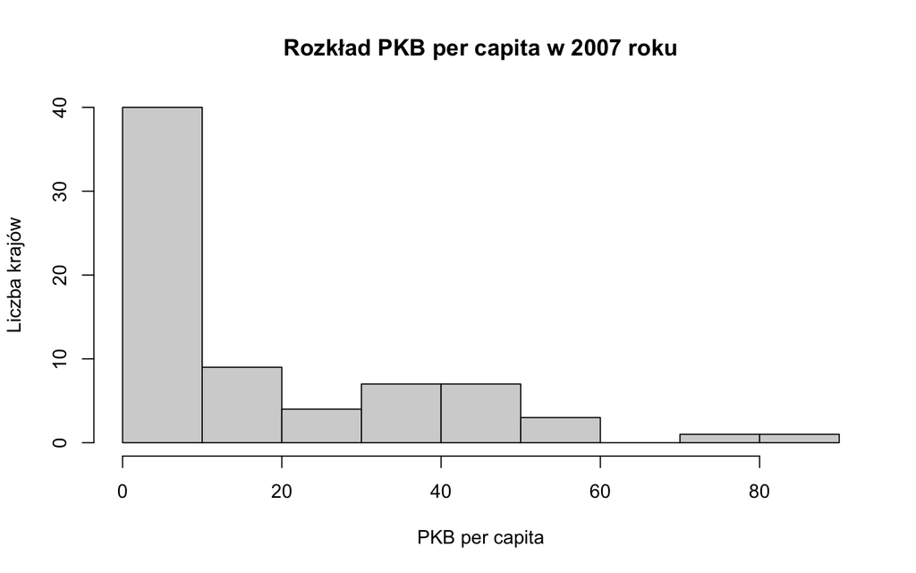

```r
hist(data$gdp2007,
     main = "Rozkład PKB per capita w 2007 roku",
     xlab = "PKB per capita",
     ylab = "Liczba krajów")
```

Jak widzimy, rozrzuty w danych są bardzo znaczące. Na podstawie powyższego wykresu spróbujemy ustalić klasyfikację wielkości gospodarki na:
$$\begin{align*}PKB\text{ }per\text{
}capita \leq 10000&\quad\mathrm{-}\quad gospodarka\text{
}slabo\text{ }rozwinieta\\
10000<PKB\text{ }per\text{ }capita \leq
25000&\quad\mathrm{-}\quad gospodarka\text{ }srednio\text{
}rozwinieta\\
PKB\text{ }per\text{ }capita>25000&\quad\mathrm{-}\quad
gospodarka\text{ }wysoko\text{ }rozwinieta\\\end{align*}$$
Sprawdźmy więc, ile byłoby krajów w każdej z kategorii, aby zdecydować, czy nasze wybrane przedziały będą odpowiednie.

```r
print(count(data[data$gdp2007 <= 10.000,]))
```

```
## # A tibble: 1 × 1
##       n
##   <int>
## 1    40
```

```r
print(count(data[data$gdp2007 > 10.000 & data$gdp2007 <= 25.000,]))
```

```
## # A tibble: 1 × 1
##       n
##   <int>
## 1    12
```

```r
print(count(data[data$gdp2007 > 25.000,]))
```

```
## # A tibble: 1 × 1
##       n
##   <int>
## 1    20
```

Jak widzimy, nasz środkowy przedział jest zbyt mało liczny w porównaniu do reszty. Musimy zatem zwiększyć jego szerokość kosztem pierwszego (zbyt licznego) przedziału. Zaproponujmy nowe przedziały:
$$\begin{align*}PKB\text{ }per\text{ }capita
\leq 5000&\quad\mathrm{-}\quad gospodarka\text{ }slabo\text{
}rozwinieta\\
5000<PKB\text{ }per\text{ }capita \leq 25000&\quad\mathrm{-}\quad
gospodarka\text{ }srednio\text{ }rozwinieta\\
PKB\text{ }per\text{ }capita>25000&\quad\mathrm{-}\quad
gospodarka\text{ }wysoko\text{ }rozwinieta\\\end{align*}$$
I poraz kolejny zweryfikujmy jego zasadność:

```r
print(count(data[data$gdp2007 <= 5.000,]))
```

```
## # A tibble: 1 × 1
##       n
##   <int>
## 1    25
```

```r
print(count(data[data$gdp2007 > 5.000 & data$gdp2007 <= 25.000,]))
```

```
## # A tibble: 1 × 1
##       n
##   <int>
## 1    27
```

```r
print(count(data[data$gdp2007 > 25.000,]))
```

```
## # A tibble: 1 × 1
##       n
##   <int>
## 1    20
```

Teraz przedziały te są w miarę możliwości równe. Możemy więc przejść do dołączenia nowej zmiennej do naszych danych. W pierwszej kolejności utworzymy wektor zawierający nasze nowe wartości:

```r
klasyfikacja2007 <- c()

for (kraj in data$gdp2007) {
  if (kraj <= 5.000) {
    klasyfikacja2007 <- append(klasyfikacja2007, "gospodarka słabo rozwinięta")
  }
  else if (kraj <= 25.000) {
    klasyfikacja2007 <- append(klasyfikacja2007, "gospodarka średnio rozwinięta")
  }
  else {
    klasyfikacja2007 <- append(klasyfikacja2007, "gospodarka wysoko rozwinięta")
  }
}

klasyfikacja2007
```

```
##  [1] "gospodarka słabo rozwinięta"   "gospodarka słabo rozwinięta"
##  [3] "gospodarka średnio rozwinięta" "gospodarka wysoko rozwinięta"
##  [5] "gospodarka średnio rozwinięta" "gospodarka wysoko rozwinięta"
##  [7] "gospodarka słabo rozwinięta"   "gospodarka średnio rozwinięta"
##  [9] "gospodarka słabo rozwinięta"   "gospodarka słabo rozwinięta"
## [11] "gospodarka wysoko rozwinięta"  "gospodarka średnio rozwinięta"
## [13] "gospodarka słabo rozwinięta"   "gospodarka słabo rozwinięta"
## [15] "gospodarka średnio rozwinięta" "gospodarka średnio rozwinięta"
## [17] "gospodarka średnio rozwinięta" "gospodarka średnio rozwinięta"
## [19] "gospodarka średnio rozwinięta" "gospodarka słabo rozwinięta"
## [21] "gospodarka wysoko rozwinięta"  "gospodarka wysoko rozwinięta"
## [23] "gospodarka wysoko rozwinięta"  "gospodarka średnio rozwinięta"
## [25] "gospodarka słabo rozwinięta"   "gospodarka wysoko rozwinięta"
## [27] "gospodarka wysoko rozwinięta"  "gospodarka słabo rozwinięta"
## [29] "gospodarka średnio rozwinięta" "gospodarka wysoko rozwinięta"
```

[output cut: 21 more lines]

Teraz możemy dołączyć nową zmienną do tabeli głównej:

```r
data <- cbind(data, klasyfikacja2007)
data <- data %>%
        rename(classification2007 = `klasyfikacja2007`)
data
```

| country | continent | gdp2007 | gdp2010 | unemployment2007 | unemployment2010 | foreignInvestments2007 | foreignInvestments2010 | gini2007 | gini2010 | classification2007 |
| --- | --- | --- | --- | --- | --- | --- | --- | --- | --- | --- |
| Albania | Europe | 3.040 | 3.580 | 16.00 | 14.10 | 6.11 | 9.14 | 30.2 | 29.5 | gospodarka słabo rozwinięta |
| Algeria | Inny | 3.850 | 3.930 | 13.80 | 9.96 | 1.25 | 1.43 | 42.4 | 42.4 | gospodarka słabo rozwinięta |
| Argentina | Americas | 12.900 | 13.600 | 8.47 | 7.71 | 2.25 | 2.68 | 46.2 | 43.6 | gospodarka średnio rozwinięta |
| Australia | Inny | 52.600 | 53.600 | 4.38 | 5.21 | 5.20 | 3.07 | 34.8 | 34.7 | gospodarka wysoko rozwinięta |
| Bahrain | Asia | 22.000 | 21.500 | 5.60 | 1.13 | 8.08 | 0.61 | 48.7 | 48.7 | gospodarka średnio rozwinięta |
| Belgium | Europe | 40.300 | 39.800 | 7.46 | 8.29 | 20.50 | 26.10 | 27.5 | 27.5 | gospodarka wysoko rozwinięta |
| Bosnia and Herzegovina | Europe | 3.670 | 3.980 | 29.00 | 27.30 | 11.70 | 2.58 | 33.1 | 33.0 | gospodarka słabo rozwinięta |
| Bulgaria | Europe | 6.050 | 6.430 | 6.88 | 10.30 | 31.20 | 3.64 | 27.5 | 27.5 | gospodarka średnio rozwinięta |
| Cambodia | Asia | 0.823 | 0.889 | 1.26 | 0.77 | 10.00 | 12.50 | 41.1 | 41.1 | gospodarka słabo rozwinięta |
| Cameroon | Inny | 1.280 | 1.280 | 3.06 | 4.11 | 0.79 | 1.95 | 57.8 | 57.8 | gospodarka słabo rozwinięta |

[output cut: 62 more lines]

Jak jednak widzimy nowa kolumna przyjmuje wartości typu `character`, a więc musimy zmienić je na typ `factor`:

```r
lvls <- c("gospodarka słabo rozwinięta", "gospodarka średnio rozwinięta",
          "gospodarka wysoko rozwinięta")
data$classification2007 <- factor(data$classification2007, lvls)
data
```

| country | continent | gdp2007 | gdp2010 | unemployment2007 | unemployment2010 | foreignInvestments2007 | foreignInvestments2010 | gini2007 | gini2010 | classification2007 |
| --- | --- | --- | --- | --- | --- | --- | --- | --- | --- | --- |
| Albania | Europe | 3.040 | 3.580 | 16.00 | 14.10 | 6.11 | 9.14 | 30.2 | 29.5 | gospodarka słabo rozwinięta |
| Algeria | Inny | 3.850 | 3.930 | 13.80 | 9.96 | 1.25 | 1.43 | 42.4 | 42.4 | gospodarka słabo rozwinięta |
| Argentina | Americas | 12.900 | 13.600 | 8.47 | 7.71 | 2.25 | 2.68 | 46.2 | 43.6 | gospodarka średnio rozwinięta |
| Australia | Inny | 52.600 | 53.600 | 4.38 | 5.21 | 5.20 | 3.07 | 34.8 | 34.7 | gospodarka wysoko rozwinięta |
| Bahrain | Asia | 22.000 | 21.500 | 5.60 | 1.13 | 8.08 | 0.61 | 48.7 | 48.7 | gospodarka średnio rozwinięta |
| Belgium | Europe | 40.300 | 39.800 | 7.46 | 8.29 | 20.50 | 26.10 | 27.5 | 27.5 | gospodarka wysoko rozwinięta |
| Bosnia and Herzegovina | Europe | 3.670 | 3.980 | 29.00 | 27.30 | 11.70 | 2.58 | 33.1 | 33.0 | gospodarka słabo rozwinięta |
| Bulgaria | Europe | 6.050 | 6.430 | 6.88 | 10.30 | 31.20 | 3.64 | 27.5 | 27.5 | gospodarka średnio rozwinięta |
| Cambodia | Asia | 0.823 | 0.889 | 1.26 | 0.77 | 10.00 | 12.50 | 41.1 | 41.1 | gospodarka słabo rozwinięta |
| Cameroon | Inny | 1.280 | 1.280 | 3.06 | 4.11 | 0.79 | 1.95 | 57.8 | 57.8 | gospodarka słabo rozwinięta |

[output cut: 62 more lines]

Z ciekawości możemy analogicznie postąpić z PKB per capita z 2010 roku, aby sprawdzić (na późniejszym etapie), czy któremuś z badanych krajów zmieniła się klasyfikacja ze względu na kryzys finansowy z lat 2008-2009.

```r
klasyfikacja2010 <- c()

for (kraj in data$gdp2010) {
  if (kraj <= 5.000) {
    klasyfikacja2010 <- append(klasyfikacja2010, "gospodarka słabo rozwinięta")
  }
  else if (kraj <= 25.000) {
    klasyfikacja2010 <- append(klasyfikacja2010, "gospodarka średnio rozwinięta")
  }
  else {
    klasyfikacja2010 <- append(klasyfikacja2010, "gospodarka wysoko rozwinięta")
  }
}

data <- cbind(data, klasyfikacja2010)
data <- data %>%
        rename(classification2010 = `klasyfikacja2010`)

data$classification2010 <- factor(data$classification2010, lvls)
data
```

| country | continent | gdp2007 | gdp2010 | unemployment2007 | unemployment2010 | foreignInvestments2007 | foreignInvestments2010 | gini2007 | gini2010 | classification2007 | classification2010 |
| --- | --- | --- | --- | --- | --- | --- | --- | --- | --- | --- | --- |
| Albania | Europe | 3.040 | 3.580 | 16.00 | 14.10 | 6.11 | 9.14 | 30.2 | 29.5 | gospodarka słabo rozwinięta | gospodarka słabo rozwinięta |
| Algeria | Inny | 3.850 | 3.930 | 13.80 | 9.96 | 1.25 | 1.43 | 42.4 | 42.4 | gospodarka słabo rozwinięta | gospodarka słabo rozwinięta |
| Argentina | Americas | 12.900 | 13.600 | 8.47 | 7.71 | 2.25 | 2.68 | 46.2 | 43.6 | gospodarka średnio rozwinięta | gospodarka średnio rozwinięta |
| Australia | Inny | 52.600 | 53.600 | 4.38 | 5.21 | 5.20 | 3.07 | 34.8 | 34.7 | gospodarka wysoko rozwinięta | gospodarka wysoko rozwinięta |
| Bahrain | Asia | 22.000 | 21.500 | 5.60 | 1.13 | 8.08 | 0.61 | 48.7 | 48.7 | gospodarka średnio rozwinięta | gospodarka średnio rozwinięta |
| Belgium | Europe | 40.300 | 39.800 | 7.46 | 8.29 | 20.50 | 26.10 | 27.5 | 27.5 | gospodarka wysoko rozwinięta | gospodarka wysoko rozwinięta |
| Bosnia and Herzegovina | Europe | 3.670 | 3.980 | 29.00 | 27.30 | 11.70 | 2.58 | 33.1 | 33.0 | gospodarka słabo rozwinięta | gospodarka słabo rozwinięta |
| Bulgaria | Europe | 6.050 | 6.430 | 6.88 | 10.30 | 31.20 | 3.64 | 27.5 | 27.5 | gospodarka średnio rozwinięta | gospodarka średnio rozwinięta |
| Cambodia | Asia | 0.823 | 0.889 | 1.26 | 0.77 | 10.00 | 12.50 | 41.1 | 41.1 | gospodarka słabo rozwinięta | gospodarka słabo rozwinięta |
| Cameroon | Inny | 1.280 | 1.280 | 3.06 | 4.11 | 0.79 | 1.95 | 57.8 | 57.8 | gospodarka słabo rozwinięta | gospodarka słabo rozwinięta |

[output cut: 62 more lines]

## 3. Badanie danych

Jako że w poprzednim etapie przygotowywaliśmy dane pod ich analizę, to w dużym stopniu zapoznaliśmy się z ich strukturą.

### 3.1. Struktura danych

Mimo wszystko, na początku ich badania jeszcze raz sprawdzimy sobie strukturę tabeli głównej. Dokonamy tego przy pomocy funkcji `str()`:

```r
str(data)
```

```
## 'data.frame':    72 obs. of  12 variables:
##  $ country               : chr  "Albania" "Algeria" "Argentina" "Australia" ...
##  $ continent             : Factor w/ 4 levels "Inny","Americas",..: 4 1 2 1 3 4 4 4 3 1 ...
##  $ gdp2007               : num  3.04 3.85 12.9 52.6 22 40.3 3.67 6.05 0.823 1.28 ...
##  $ gdp2010               : num  3.58 3.93 13.6 53.6 21.5 39.8 3.98 6.43 0.889 1.28 ...
##  $ unemployment2007      : num  16 13.8 8.47 4.38 5.6 7.46 29 6.88 1.26 3.06 ...
##  $ unemployment2010      : num  14.1 9.96 7.71 5.21 1.13 8.29 27.3 10.3 0.77 4.11 ...
##  $ foreignInvestments2007: num  6.11 1.25 2.25 5.2 8.08 20.5 11.7 31.2 10 0.79 ...
##  $ foreignInvestments2010: num  9.14 1.43 2.68 3.07 0.61 26.1 2.58 3.64 12.5 1.95 ...
##  $ gini2007              : num  30.2 42.4 46.2 34.8 48.7 27.5 33.1 27.5 41.1 57.8 ...
##  $ gini2010              : num  29.5 42.4 43.6 34.7 48.7 27.5 33 27.5 41.1 57.8 ...
##  $ classification2007    : Factor w/ 3 levels "gospodarka słabo rozwinięta",..: 1 1 2 3 2 3 1 2 1 1 ...
##  $ classification2010    : Factor w/ 3 levels "gospodarka słabo rozwinięta",..: 1 1 2 3 2 3 1 2 1 1 ...
```

Jak możemy zauważyć, mamy 1 kolumnę typu `character`, 8 kolumn typu `num` oraz 3 kolumny typu `factor`. W ramach przypomnienia wyświetlimy jeszcze poziomy wszystkich trzech zmiennych typu `factor`:

```r
levels(data$continent)
```

```
## [1] "Inny"     "Americas" "Asia"     "Europe"
```

```r
levels(data$classification2007)
```

```
## [1] "gospodarka słabo rozwinięta"   "gospodarka średnio rozwinięta"
## [3] "gospodarka wysoko rozwinięta"
```

```r
levels(data$classification2010)
```

```
## [1] "gospodarka słabo rozwinięta"   "gospodarka średnio rozwinięta"
## [3] "gospodarka wysoko rozwinięta"
```

Jak widzimy, poziomy dwóch ostatnich są identyczne, ponieważ zmienne odpowiadają nam na to samo pytanie, ale dla danych z innego roku. Natomiast pierwsza kolumna odpowiada za nazwę kontynentu, na którym leży dane państwo. Pamiętajmy jednak ze wcześniejszego przygotowywania danych, że dane z wartością `Inny` w kolumnie `continent` nie mogą być analizowane pod kątem kontynentu ze względu na ich brak reprezentatywności względem części świata, z których pochodzą (mała liczba).

### 3.2. Statystyki opisowe

W celach wyznaczenia podstawowych statystyk opisowych (oczywiście tylko dla zmiennych ilościowych) posłużymy się funkcją `summary()`:

```r
summary(data[3:10])
```

```
##     gdp2007          gdp2010       unemployment2007 unemployment2010
##  Min.   : 0.676   Min.   : 0.709   Min.   : 0.400   Min.   : 0.620
##  1st Qu.: 4.202   1st Qu.: 4.647   1st Qu.: 4.008   1st Qu.: 4.510
##  Median : 8.805   Median : 8.695   Median : 6.285   Median : 7.420
##  Mean   :17.777   Mean   :17.534   Mean   : 7.414   Mean   : 8.121
##  3rd Qu.:32.425   3rd Qu.:32.225   3rd Qu.: 8.998   3rd Qu.:10.045
##  Max.   :81.300   Max.   :81.300   Max.   :29.000   Max.   :27.300
##  foreignInvestments2007 foreignInvestments2010    gini2007        gini2010
##  Min.   : 0.100         Min.   : 0.130         Min.   :25.60   Min.   :25.60
##  1st Qu.: 2.975         1st Qu.: 1.425         1st Qu.:32.15   1st Qu.:32.15
##  Median : 5.170         Median : 2.905         Median :38.75   Median :38.70
##  Mean   : 8.263         Mean   : 4.962         Mean   :40.88   Mean   :40.72
##  3rd Qu.: 8.590         3rd Qu.: 5.053         3rd Qu.:51.20   3rd Qu.:51.20
##  Max.   :86.500         Max.   :36.200         Max.   :58.80   Max.   :58.80
```

Oprócz tego wyliczymy jeszcze współczynnik zmienności, za pomocą wcześniej już zdefiniowanej funkcji `wsp_zmiennosci()`, dla każdej z kolumn:

```r
sapply(data[3:10], wsp_zmiennosci)
```

```
##                gdp2007                gdp2010       unemployment2007
##              1.0735210              1.0470213              0.6916666
##       unemployment2010 foreignInvestments2007 foreignInvestments2010
##              0.6430898              1.4327581              1.3291179
##               gini2007               gini2010
##              0.2496211              0.2492509
```

Opierając się więc o informację ze [strony o statystyce](https://obliczeniastatystyczne.pl/wspolczynnik-zmiennosci/), odnośnie interpretacji współczynnika zmienności tj.:
$$\begin{align*}Wspolczynnik\text{
}zmiennosci \leq 0.25&\quad\mathrm{-}\quad mala\text{ }zmiennosc\\
0.25<Wspolczynnik\text{ }zmiennosci\leq 0.45&\quad\mathrm{-}\quad
przecietna\text{ }zmiennosc\\
0.45<Wspolczynnik\text{ }zmiennosci\leq 1&\quad\mathrm{-}\quad
silna\text{ }zmiennosc\\
Wpolczynnik\text{ }zmiennosci>1&\quad\mathrm{-}\quad bardzo\text{
}silna\text{ }zmiennosc\\\end{align*}$$
Możemy stwierdzić, że nasze dane charakteryzują się w większości silną lub bardzo silną zmiennością. Tylko współczynnik Giniego, który odpowiada za mierzenie nierówności społecznych, ma zmienność wahającą się pomiędzy słabą a przeciętną.

Wykonamy teraz te same operacje na zmiennych podzielonych ze względu na kontynent i spróbujemy odpowiedzieć na pytanie, czy zmienność ta różni się pomiędzy kontynentami (tj. w naszych danych: Amerykami, Europą i Azją) oraz czy jest sens analizować dane według takiego grupowania - ewentualnie zaproponujemy inne. Zacznijmy od wywołania funkcji `describeBy()`:

```r
describeBy(data[3:10], group = data$continent)
```

```
##
##  Descriptive statistics by group
## group: Inny
##                        vars  n  mean    sd median trimmed  mad   min   max
## gdp2007                   1 10 11.66 17.83   3.72    7.92 3.46  0.68 52.60
## gdp2010                   2 10 11.85 17.86   3.90    8.03 3.51  0.71 53.60
## unemployment2007          3 10 10.23  6.82   9.18    9.10 5.81  3.06 26.50
## unemployment2010          4 10  9.72  5.83   8.41    8.55 2.52  4.11 24.70
## foreignInvestments2007    5 10  3.54  2.31   3.37    3.22 1.65  0.79  8.88
## foreignInvestments2010    6 10  2.24  1.29   2.42    2.24 1.52  0.20  4.30
## gini2007                  7 10 38.39  9.49  35.10   37.31 5.71 27.60 57.80
## gini2010                  8 10 38.27  9.59  35.10   37.16 6.52 27.60 57.80
##                        range  skew kurtosis   se
## gdp2007                51.92  1.39     0.20 5.64
## gdp2010                52.89  1.41     0.34 5.65
## unemployment2007       23.44  1.10     0.51 2.16
## unemployment2010       20.59  1.56     1.50 1.84
## foreignInvestments2007  8.09  0.96     0.17 0.73
## foreignInvestments2010  4.10 -0.03    -1.43 0.41
## gini2007               30.20  0.86    -0.68 3.00
## gini2010               30.20  0.85    -0.71 3.03
## ------------------------------------------------------------
## group: Americas
##                        vars  n  mean   sd median trimmed  mad   min   max range
## gdp2007                   1 16  9.74 9.57   7.34    8.01 4.26  1.67 42.10 40.43
## gdp2010                   2 16 10.10 9.37   7.36    8.48 4.21  1.67 41.20 39.53
## unemployment2007          3 16  6.12 2.42   5.35    6.04 2.34  3.14 10.30  7.16
## unemployment2010          4 16  6.52 2.66   6.23    6.31 2.92  3.58 12.40  8.82
## foreignInvestments2007    5 16  5.29 2.85   5.26    5.28 3.60  0.38 10.40 10.02
## foreignInvestments2010    6 16  3.84 2.28   3.13    3.75 2.24  0.24  8.66  8.42
## gini2007                  7 16 45.48 9.48  45.75   45.54 9.86 31.30 58.80 27.50
## gini2010                  8 16 44.93 9.26  45.25   44.91 8.82 31.30 58.80 27.50
##                         skew kurtosis   se
## gdp2007                 2.32     5.26 2.39
## gdp2010                 2.18     4.72 2.34
## unemployment2007        0.42    -1.41 0.61
## unemployment2010        0.68    -0.64 0.66
## foreignInvestments2007 -0.13    -1.00 0.71
## foreignInvestments2010  0.50    -0.77 0.57
## gini2007               -0.16    -1.41 2.37
```

[output cut: 26 more lines]

```
## unemployment2007          3 26  8.86  5.90   7.56    8.06  3.17  2.25 29.0
## unemployment2010          4 26 11.02  5.51   9.25   10.50  3.40  3.52 27.3
## foreignInvestments2007    5 26 12.87 17.42   6.72    9.74  5.16  0.61 86.5
## foreignInvestments2010    6 26  5.30  6.42   2.77    4.23  2.14  0.13 26.1
## gini2007                  7 26 39.42 11.40  34.00   38.90  9.27 25.60 58.8
## gini2010                  8 26 39.37 11.41  34.40   38.80 10.08 25.60 58.8
##                        range skew kurtosis   se
## gdp2007                78.26 0.73    -0.44 4.35
## gdp2010                77.72 0.81    -0.17 4.16
## unemployment2007       26.75 1.77     3.09 1.16
## unemployment2010       23.78 1.16     0.92 1.08
## foreignInvestments2007 85.89 2.95     9.45 3.42
## foreignInvestments2010 25.97 1.84     2.51 1.26
## gini2007               33.20 0.48    -1.44 2.24
## gini2010               33.20 0.49    -1.43 2.24
```

Oczywiście funkcja wywołała się również dla kontynentu `Inny`, ale pamiętajmy, że jest to zlepek krajów z Afryki i Oceanii, a więc statystyki te są tak naprawdę bezużyteczne. Przechodząc jednak do pozostałych grup, tak jak wcześniej, obliczymy współczynnik zmienności. W tym celu stworzymy tabele pomocnicze dla każdego z kontynentów:

```r
europa <- data %>%
          filter(data$continent == "Europe")
europa
```

| country | continent | gdp2007 | gdp2010 | unemployment2007 | unemployment2010 | foreignInvestments2007 | foreignInvestments2010 | gini2007 | gini2010 | classification2007 | classification2010 |
| --- | --- | --- | --- | --- | --- | --- | --- | --- | --- | --- | --- |
| Albania | Europe | 3.04 | 3.58 | 16.00 | 14.10 | 6.11 | 9.14 | 30.2 | 29.5 | gospodarka słabo rozwinięta | gospodarka słabo rozwinięta |
| Belgium | Europe | 40.30 | 39.80 | 7.46 | 8.29 | 20.50 | 26.10 | 27.5 | 27.5 | gospodarka wysoko rozwinięta | gospodarka wysoko rozwinięta |
| Bosnia and Herzegovina | Europe | 3.67 | 3.98 | 29.00 | 27.30 | 11.70 | 2.58 | 33.1 | 33.0 | gospodarka słabo rozwinięta | gospodarka słabo rozwinięta |
| Bulgaria | Europe | 6.05 | 6.43 | 6.88 | 10.30 | 31.20 | 3.64 | 27.5 | 27.5 | gospodarka średnio rozwinięta | gospodarka średnio rozwinięta |
| Croatia | Europe | 12.60 | 11.80 | 9.91 | 11.60 | 7.66 | 2.55 | 53.7 | 53.7 | gospodarka średnio rozwinięta | gospodarka średnio rozwinięta |
| Czech Republic | Europe | 16.70 | 16.50 | 5.32 | 7.28 | 7.26 | 4.86 | 26.0 | 26.6 | gospodarka średnio rozwinięta | gospodarka średnio rozwinięta |
| Finland | Europe | 46.20 | 43.60 | 6.85 | 8.39 | 8.57 | 4.90 | 28.3 | 27.7 | gospodarka wysoko rozwinięta | gospodarka wysoko rozwinięta |
| France | Europe | 36.50 | 35.60 | 7.66 | 8.87 | 3.15 | 1.47 | 32.4 | 33.7 | gospodarka wysoko rozwinięta | gospodarka wysoko rozwinięta |
| Germany | Europe | 37.80 | 37.80 | 8.66 | 6.97 | 1.48 | 2.53 | 25.6 | 25.6 | gospodarka wysoko rozwinięta | gospodarka wysoko rozwinięta |
| Greece | Europe | 24.10 | 21.60 | 8.40 | 12.70 | 0.61 | 0.18 | 34.0 | 34.1 | gospodarka średnio rozwinięta | gospodarka średnio rozwinięta |

[output cut: 16 more lines]

```r
azja <- data %>%
          filter(data$continent == "Asia")
azja
```

| country | continent | gdp2007 | gdp2010 | unemployment2007 | unemployment2010 | foreignInvestments2007 | foreignInvestments2010 | gini2007 | gini2010 | classification2007 | classification2010 |
| --- | --- | --- | --- | --- | --- | --- | --- | --- | --- | --- | --- |
| Bahrain | Asia | 22.000 | 21.500 | 5.60 | 1.13 | 8.08 | 0.61 | 48.7 | 48.7 | gospodarka średnio rozwinięta | gospodarka średnio rozwinięta |
| Cambodia | Asia | 0.823 | 0.889 | 1.26 | 0.77 | 10.00 | 12.50 | 41.1 | 41.1 | gospodarka słabo rozwinięta | gospodarka słabo rozwinięta |
| China | Asia | 4.320 | 5.650 | 4.00 | 4.10 | 4.40 | 4.00 | 57.8 | 57.8 | gospodarka słabo rozwinięta | gospodarka średnio rozwinięta |
| Hong Kong, China | Asia | 36.400 | 38.100 | 4.01 | 4.33 | 29.40 | 36.20 | 45.2 | 45.2 | gospodarka wysoko rozwinięta | gospodarka wysoko rozwinięta |
| Indonesia | Asia | 2.380 | 2.700 | 8.06 | 5.61 | 1.60 | 2.03 | 30.1 | 30.1 | gospodarka słabo rozwinięta | gospodarka słabo rozwinięta |
| Iran | Asia | 5.230 | 5.380 | 10.80 | 13.70 | 0.58 | 0.75 | 30.1 | 30.1 | gospodarka średnio rozwinięta | gospodarka średnio rozwinięta |
| Israel | Asia | 31.900 | 33.000 | 9.38 | 8.48 | 4.78 | 2.93 | 41.1 | 42.5 | gospodarka wysoko rozwinięta | gospodarka wysoko rozwinięta |
| Japan | Asia | 34.000 | 32.900 | 3.89 | 5.10 | 0.47 | 0.13 | 34.6 | 34.6 | gospodarka wysoko rozwinięta | gospodarka wysoko rozwinięta |
| Jordan | Asia | 4.520 | 4.870 | 13.10 | 12.50 | 15.30 | 6.22 | 33.2 | 33.7 | gospodarka słabo rozwinięta | gospodarka słabo rozwinięta |
| Kuwait | Asia | 41.100 | 32.600 | 1.50 | 1.82 | 0.10 | 1.13 | 30.2 | 30.2 | gospodarka wysoko rozwinięta | gospodarka wysoko rozwinięta |

[output cut: 10 more lines]

```r
ameryki <- data %>%
           filter(data$continent == "Americas")
ameryki
```

| country | continent | gdp2007 | gdp2010 | unemployment2007 | unemployment2010 | foreignInvestments2007 | foreignInvestments2010 | gini2007 | gini2010 | classification2007 | classification2010 |
| --- | --- | --- | --- | --- | --- | --- | --- | --- | --- | --- | --- |
| Argentina | Americas | 12.90 | 13.60 | 8.47 | 7.71 | 2.25 | 2.68 | 46.2 | 43.6 | gospodarka średnio rozwinięta | gospodarka średnio rozwinięta |
| Canada | Americas | 42.10 | 41.20 | 6.04 | 8.06 | 8.20 | 1.84 | 40.1 | 40.1 | gospodarka wysoko rozwinięta | gospodarka wysoko rozwinięta |
| Chile | Americas | 11.20 | 11.80 | 8.43 | 8.42 | 7.81 | 7.38 | 57.8 | 57.8 | gospodarka średnio rozwinięta | gospodarka średnio rozwinięta |
| Colombia | Americas | 4.94 | 5.21 | 10.30 | 11.00 | 4.31 | 2.24 | 57.8 | 57.8 | gospodarka słabo rozwinięta | gospodarka średnio rozwinięta |
| Costa Rica | Americas | 9.65 | 10.10 | 4.49 | 7.17 | 8.34 | 5.06 | 42.1 | 42.1 | gospodarka średnio rozwinięta | gospodarka średnio rozwinięta |
| Dominican Republic | Americas | 5.27 | 5.72 | 5.16 | 5.21 | 5.12 | 3.38 | 48.9 | 47.3 | gospodarka średnio rozwinięta | gospodarka średnio rozwinięta |
| Ecuador | Americas | 5.06 | 5.33 | 3.14 | 4.09 | 0.38 | 0.24 | 53.4 | 48.8 | gospodarka średnio rozwinięta | gospodarka średnio rozwinięta |
| Honduras | Americas | 2.11 | 2.09 | 3.21 | 4.12 | 7.82 | 3.83 | 45.2 | 45.2 | gospodarka słabo rozwinięta | gospodarka słabo rozwinięta |
| Jamaica | Americas | 5.44 | 5.03 | 9.75 | 12.40 | 6.34 | 1.41 | 45.3 | 45.3 | gospodarka średnio rozwinięta | gospodarka średnio rozwinięta |
| Mexico | Americas | 9.29 | 9.00 | 3.63 | 5.30 | 2.96 | 2.89 | 31.3 | 31.3 | gospodarka średnio rozwinięta | gospodarka średnio rozwinięta |

[output cut: 6 more lines]

Teraz dla każdej z tabeli możemy wywołać funkcję `wsp_zmiennosci()` (dla odpowiednich kolumn) oraz przypisać wyniki do list, ponieważ mogą się one przydać później:

```r
statystyki_europa <- sapply(europa[3:10], wsp_zmiennosci)
statystyki_europa
```

```
##                gdp2007                gdp2010       unemployment2007
##              0.7833422              0.7747187              0.6661453
##       unemployment2010 foreignInvestments2007 foreignInvestments2010
##              0.5000539              1.3534483              1.2119983
##               gini2007               gini2010
##              0.2892666              0.2897477
```

```r
statystyki_azja <- sapply(azja[3:10], wsp_zmiennosci)
statystyki_azja
```

```
##                gdp2007                gdp2010       unemployment2007
##              1.1540152              1.1289832              0.6698716
##       unemployment2010 foreignInvestments2007 foreignInvestments2010
##              0.7699604              1.1573585              1.4350727
##               gini2007               gini2010
##              0.2218893              0.2241738
```

```r
statystyki_ameryki <- sapply(ameryki[3:10], wsp_zmiennosci)
statystyki_ameryki
```

```
##                gdp2007                gdp2010       unemployment2007
##              0.9825730              0.9270417              0.3955266
##       unemployment2010 foreignInvestments2007 foreignInvestments2010
##              0.4075660              0.5388892              0.5940299
##               gini2007               gini2010
##              0.2083887              0.2060382
```

Przydałoby się, abyśmy następnie zobaczyli, jakie są różnice w zmienności danych statystyk pomiędzy kontynentami:

- Europa, a Ameryki:

```r
statystyki_europa - statystyki_ameryki
```

```
##                gdp2007                gdp2010       unemployment2007
##            -0.19923078            -0.15232300             0.27061866
##       unemployment2010 foreignInvestments2007 foreignInvestments2010
##             0.09248789             0.81455904             0.61796833
##               gini2007               gini2010
##             0.08087790             0.08370956
```

Zróżnicowanie statystyk krajów europejskich jest większe od tych z Ameryk (wyjątkiem jest wpółczynnik zmienności PKB per capita).

- Europa, a Azja:

```r
statystyki_europa - statystyki_azja
```

```
##                gdp2007                gdp2010       unemployment2007
##           -0.370673008           -0.354264577           -0.003726305
##       unemployment2010 foreignInvestments2007 foreignInvestments2010
##           -0.269906510            0.196089739           -0.223074485
##               gini2007               gini2010
##            0.067377333            0.065573973
```

Zmienność większości statystyk krajów azjatyckich jest zauważalnie większa niż krajów europejskich. Ciekawym zjawiskiem jest jednak rozstrzał pomiędzy zróżnicowaniem inwestycji zagranicznych z 2007 i 2010 roku.

- Azja, a Ameryki:

```r
statystyki_azja - statystyki_ameryki
```

```
##                gdp2007                gdp2010       unemployment2007
##             0.17144223             0.20194158             0.27434496
##       unemployment2010 foreignInvestments2007 foreignInvestments2010
##             0.36239440             0.61846930             0.84104282
##               gini2007               gini2010
##             0.01350057             0.01813559
```

W tym przypadku każda ze statystyk krajów azjatyckich cechuje się większą zmiennością niż te krajów Ameryk. Szczególnie widoczną różnicą jest zmienność w inwestycjach zagranicznych na terenach badanych państw.

Kolejnym możliwym podziałem będzie klasyfikacja ze względu na stopień rozwinięcia gospodarki. Będziemy więc operować na kolumnach `classification2007` oraz `classification2010`. Zacznijmy jednak od sprawdzenia, czy którykolwiek z badanych krajów zmienił swoją dotychczasową grupę po kryzysie finansowym z lat 2008-2009:

```r
print(count(data[data$classification2007 != data$classification2010,]))
```

```
##   n
## 1 6
```

Jak widać, jest 6 takich krajów. Wyświetlmy je:

```r
data[data$classification2007 != data$classification2010,]
```

|  | country | continent | gdp2007 | gdp2010 | unemployment2007 | unemployment2010 | foreignInvestments2007 | foreignInvestments2010 | gini2007 | gini2010 | classification2007 | classification2010 |
| --- | --- | --- | --- | --- | --- | --- | --- | --- | --- | --- | --- | --- |
| 13 | China | Asia | 4.32 | 5.65 | 4.00 | 4.10 | 4.40 | 4.00 | 57.8 | 57.8 | gospodarka słabo rozwinięta | gospodarka średnio rozwinięta |
| 14 | Colombia | Americas | 4.94 | 5.21 | 10.30 | 11.00 | 4.31 | 2.24 | 57.8 | 57.8 | gospodarka słabo rozwinięta | gospodarka średnio rozwinięta |
| 50 | Paraguay | Americas | 4.52 | 5.16 | 4.71 | 4.57 | 0.59 | 2.53 | 34.0 | 34.0 | gospodarka słabo rozwinięta | gospodarka średnio rozwinięta |
| 51 | Peru | Americas | 4.40 | 5.14 | 4.04 | 3.58 | 5.37 | 5.73 | 32.2 | 32.2 | gospodarka słabo rozwinięta | gospodarka średnio rozwinięta |
| 57 | Serbia | Europe | 4.97 | 5.21 | 18.10 | 19.20 | 10.20 | 4.05 | 51.2 | 51.2 | gospodarka słabo rozwinięta | gospodarka średnio rozwinięta |
| 67 | Thailand | Asia | 4.78 | 5.08 | 1.18 | 0.62 | 3.28 | 4.32 | 51.2 | 51.2 | gospodarka słabo rozwinięta | gospodarka średnio rozwinięta |

Możemy zauważyć, że wszystkie z tych państw “awansowały” z gospodarek słabo rozwiniętych na średnio rozwinięte. Dodatkowo możemy obliczyć, o ile zmieniły się ich PKB per capita:

```r
zmienione_kraje <-data[data$classification2007 != data$classification2010,]

zmienione_kraje$gdp2010 - zmienione_kraje$gdp2007
```

```
## [1] 1.33 0.27 0.64 0.74 0.24 0.30
```

Widzimy, że prawie wszystkie te zmiany nie przekroczyły 1 tys. dolarów. Z uwagi na to oraz na mniejszą liczność danych z krajów o słabo rozwiniętej gospodarce przyjmijmy, że będziemy wyliczać statystyki w odniesieniu do podziału gospodarek z 2007 roku. Zacznijmy więc tak jak poprzednio od wyliczenia podstawowych statystyk opisowych:

```r
describeBy(data[3:10], group = data$classification2007)
```

```
##
##  Descriptive statistics by group
## group: gospodarka słabo rozwinięta
##                        vars  n  mean    sd median trimmed   mad   min   max
## gdp2007                   1 25  2.89  1.38   2.66    2.90  1.76  0.68  4.97
## gdp2010                   2 25  3.18  1.56   3.09    3.20  2.11  0.71  5.65
## unemployment2007          3 25  8.18  6.51   7.20    7.43  5.92  0.40 29.00
## unemployment2010          4 25  7.75  6.18   6.55    6.95  4.36  0.62 27.30
## foreignInvestments2007    5 25  5.29  3.92   4.31    4.95  4.02  0.59 15.30
## foreignInvestments2010    6 25  4.43  4.83   2.92    3.51  2.21  0.51 23.50
## gini2007                  7 25 41.55 10.09  40.00   41.04 11.56 30.10 58.80
## gini2010                  8 25 41.42 10.24  40.00   40.94 11.56 29.50 58.80
##                        range skew kurtosis   se
## gdp2007                 4.29 0.06    -1.43 0.28
## gdp2010                 4.94 0.05    -1.43 0.31
## unemployment2007       28.60 1.29     1.80 1.30
## unemployment2010       26.68 1.33     1.85 1.24
## foreignInvestments2007 14.71 0.73    -0.39 0.78
## foreignInvestments2010 22.99 2.57     7.11 0.97
## gini2007               28.70 0.49    -1.38 2.02
## gini2010               29.30 0.46    -1.38 2.05
## ------------------------------------------------------------
## group: gospodarka średnio rozwinięta
##                        vars  n  mean   sd median trimmed   mad   min  max range
## gdp2007                   1 27 11.40 5.78   9.65   10.94  5.49  5.06 24.1 19.04
## gdp2010                   2 27 11.54 5.38  10.30   11.22  6.35  5.03 21.6 16.57
## unemployment2007          3 27  8.29 4.91   7.96    7.46  3.31  3.14 26.5 23.36
## unemployment2010          4 27  8.98 5.12   7.65    8.42  4.52  1.13 24.7 23.57
## foreignInvestments2007    5 27  6.59 6.81   5.79    5.23  2.99  0.38 31.2 30.82
## foreignInvestments2010    6 27  3.67 3.63   2.89    3.12  2.55  0.18 18.3 18.12
## gini2007                  7 27 41.94 9.60  42.10   42.07 13.49 26.00 57.8 31.80
## gini2010                  8 27 41.50 9.40  42.10   41.52 13.49 26.60 57.8 31.20
##                         skew kurtosis   se
## gdp2007                 0.73    -0.77 1.11
## gdp2010                 0.52    -1.10 1.04
## unemployment2007        2.16     5.18 0.94
## unemployment2010        1.17     1.47 0.99
## foreignInvestments2007  2.42     5.60 1.31
## foreignInvestments2010  2.39     7.07 0.70
## gini2007               -0.09    -1.54 1.85
## gini2010               -0.02    -1.54 1.81
## ------------------------------------------------------------
## group: gospodarka wysoko rozwinięta
##                        vars  n  mean    sd median trimmed   mad   min   max
## gdp2007                   1 20 44.98 13.58  41.60   42.73  9.41 27.20 81.30
## gdp2010                   2 20 43.56 13.47  40.50   41.24 11.19 25.70 81.30
## unemployment2007          3 20  5.27  2.25   4.68    5.22  2.13  1.50  9.38
## unemployment2010          4 20  7.42  4.00   7.26    6.79  2.71  1.82 19.90
## foreignInvestments2007    5 20 14.24 19.69   7.20   10.37  6.12  0.10 86.50
## foreignInvestments2010    6 20  7.37 10.30   2.75    5.30  3.28  0.13 36.20
## gini2007                  7 20 38.60 11.25  33.75   37.59  9.19 25.60 58.80
## gini2010                  8 20 38.80 11.23  34.65   37.83 10.38 25.60 58.80
##                        range skew kurtosis   se
## gdp2007                54.10 1.30     1.13 3.04
## gdp2010                55.60 1.37     1.41 3.01
## unemployment2007        7.88 0.19    -1.18 0.50
## unemployment2010       18.08 1.52     2.51 0.90
## foreignInvestments2007 86.40 2.45     6.19 4.40
## foreignInvestments2010 36.07 1.50     1.01 2.30
## gini2007               33.20 0.68    -1.11 2.52
## gini2010               33.20 0.64    -1.13 2.51
```

Analogicznie do wcześniejszej analizy względem kontynentów, wyliczymy teraz współczynnik zmienności:

```r
slabe <- data %>%
          filter(data$classification2007 == "gospodarka słabo rozwinięta")
slabe
```

| country | continent | gdp2007 | gdp2010 | unemployment2007 | unemployment2010 | foreignInvestments2007 | foreignInvestments2010 | gini2007 | gini2010 | classification2007 | classification2010 |
| --- | --- | --- | --- | --- | --- | --- | --- | --- | --- | --- | --- |
| Albania | Europe | 3.040 | 3.580 | 16.00 | 14.10 | 6.11 | 9.14 | 30.2 | 29.5 | gospodarka słabo rozwinięta | gospodarka słabo rozwinięta |
| Algeria | Inny | 3.850 | 3.930 | 13.80 | 9.96 | 1.25 | 1.43 | 42.4 | 42.4 | gospodarka słabo rozwinięta | gospodarka słabo rozwinięta |
| Bosnia and Herzegovina | Europe | 3.670 | 3.980 | 29.00 | 27.30 | 11.70 | 2.58 | 33.1 | 33.0 | gospodarka słabo rozwinięta | gospodarka słabo rozwinięta |
| Cambodia | Asia | 0.823 | 0.889 | 1.26 | 0.77 | 10.00 | 12.50 | 41.1 | 41.1 | gospodarka słabo rozwinięta | gospodarka słabo rozwinięta |
| Cameroon | Inny | 1.280 | 1.280 | 3.06 | 4.11 | 0.79 | 1.95 | 57.8 | 57.8 | gospodarka słabo rozwinięta | gospodarka słabo rozwinięta |
| China | Asia | 4.320 | 5.650 | 4.00 | 4.10 | 4.40 | 4.00 | 57.8 | 57.8 | gospodarka słabo rozwinięta | gospodarka średnio rozwinięta |
| Colombia | Americas | 4.940 | 5.210 | 10.30 | 11.00 | 4.31 | 2.24 | 57.8 | 57.8 | gospodarka słabo rozwinięta | gospodarka średnio rozwinięta |
| Egypt | Inny | 2.970 | 3.310 | 8.80 | 8.76 | 8.88 | 2.92 | 31.3 | 30.2 | gospodarka słabo rozwinięta | gospodarka słabo rozwinięta |
| Honduras | Americas | 2.110 | 2.090 | 3.21 | 4.12 | 7.82 | 3.83 | 45.2 | 45.2 | gospodarka słabo rozwinięta | gospodarka słabo rozwinięta |
| Indonesia | Asia | 2.380 | 2.700 | 8.06 | 5.61 | 1.60 | 2.03 | 30.1 | 30.1 | gospodarka słabo rozwinięta | gospodarka słabo rozwinięta |

[output cut: 15 more lines]

```r
srednie <- data %>%
          filter(data$classification2007 == "gospodarka średnio rozwinięta")
srednie
```

| country | continent | gdp2007 | gdp2010 | unemployment2007 | unemployment2010 | foreignInvestments2007 | foreignInvestments2010 | gini2007 | gini2010 | classification2007 | classification2010 |
| --- | --- | --- | --- | --- | --- | --- | --- | --- | --- | --- | --- |
| Argentina | Americas | 12.90 | 13.60 | 8.47 | 7.71 | 2.25 | 2.68 | 46.2 | 43.6 | gospodarka średnio rozwinięta | gospodarka średnio rozwinięta |
| Bahrain | Asia | 22.00 | 21.50 | 5.60 | 1.13 | 8.08 | 0.61 | 48.7 | 48.7 | gospodarka średnio rozwinięta | gospodarka średnio rozwinięta |
| Bulgaria | Europe | 6.05 | 6.43 | 6.88 | 10.30 | 31.20 | 3.64 | 27.5 | 27.5 | gospodarka średnio rozwinięta | gospodarka średnio rozwinięta |
| Chile | Americas | 11.20 | 11.80 | 8.43 | 8.42 | 7.81 | 7.38 | 57.8 | 57.8 | gospodarka średnio rozwinięta | gospodarka średnio rozwinięta |
| Costa Rica | Americas | 9.65 | 10.10 | 4.49 | 7.17 | 8.34 | 5.06 | 42.1 | 42.1 | gospodarka średnio rozwinięta | gospodarka średnio rozwinięta |
| Croatia | Europe | 12.60 | 11.80 | 9.91 | 11.60 | 7.66 | 2.55 | 53.7 | 53.7 | gospodarka średnio rozwinięta | gospodarka średnio rozwinięta |
| Czech Republic | Europe | 16.70 | 16.50 | 5.32 | 7.28 | 7.26 | 4.86 | 26.0 | 26.6 | gospodarka średnio rozwinięta | gospodarka średnio rozwinięta |
| Dominican Republic | Americas | 5.27 | 5.72 | 5.16 | 5.21 | 5.12 | 3.38 | 48.9 | 47.3 | gospodarka średnio rozwinięta | gospodarka średnio rozwinięta |
| Ecuador | Americas | 5.06 | 5.33 | 3.14 | 4.09 | 0.38 | 0.24 | 53.4 | 48.8 | gospodarka średnio rozwinięta | gospodarka średnio rozwinięta |
| Greece | Europe | 24.10 | 21.60 | 8.40 | 12.70 | 0.61 | 0.18 | 34.0 | 34.1 | gospodarka średnio rozwinięta | gospodarka średnio rozwinięta |

[output cut: 17 more lines]

```r
silne <- data %>%
           filter(data$classification2007 == "gospodarka wysoko rozwinięta")
silne
```

| country | continent | gdp2007 | gdp2010 | unemployment2007 | unemployment2010 | foreignInvestments2007 | foreignInvestments2010 | gini2007 | gini2010 | classification2007 | classification2010 |
| --- | --- | --- | --- | --- | --- | --- | --- | --- | --- | --- | --- |
| Australia | Inny | 52.6 | 53.6 | 4.38 | 5.21 | 5.20 | 3.07 | 34.8 | 34.7 | gospodarka wysoko rozwinięta | gospodarka wysoko rozwinięta |
| Belgium | Europe | 40.3 | 39.8 | 7.46 | 8.29 | 20.50 | 26.10 | 27.5 | 27.5 | gospodarka wysoko rozwinięta | gospodarka wysoko rozwinięta |
| Canada | Americas | 42.1 | 41.2 | 6.04 | 8.06 | 8.20 | 1.84 | 40.1 | 40.1 | gospodarka wysoko rozwinięta | gospodarka wysoko rozwinięta |
| Finland | Europe | 46.2 | 43.6 | 6.85 | 8.39 | 8.57 | 4.90 | 28.3 | 27.7 | gospodarka wysoko rozwinięta | gospodarka wysoko rozwinięta |
| France | Europe | 36.5 | 35.6 | 7.66 | 8.87 | 3.15 | 1.47 | 32.4 | 33.7 | gospodarka wysoko rozwinięta | gospodarka wysoko rozwinięta |
| Germany | Europe | 37.8 | 37.8 | 8.66 | 6.97 | 1.48 | 2.53 | 25.6 | 25.6 | gospodarka wysoko rozwinięta | gospodarka wysoko rozwinięta |
| Hong Kong, China | Asia | 36.4 | 38.1 | 4.01 | 4.33 | 29.40 | 36.20 | 45.2 | 45.2 | gospodarka wysoko rozwinięta | gospodarka wysoko rozwinięta |
| Iceland | Europe | 53.6 | 48.2 | 2.25 | 7.56 | 31.70 | 1.87 | 31.9 | 31.9 | gospodarka wysoko rozwinięta | gospodarka wysoko rozwinięta |
| Ireland | Europe | 52.2 | 46.4 | 4.98 | 14.50 | 22.20 | 17.00 | 30.1 | 30.1 | gospodarka wysoko rozwinięta | gospodarka wysoko rozwinięta |
| Israel | Asia | 31.9 | 33.0 | 9.38 | 8.48 | 4.78 | 2.93 | 41.1 | 42.5 | gospodarka wysoko rozwinięta | gospodarka wysoko rozwinięta |

[output cut: 10 more lines]

```r
gospodarki_slabo_rozwiniete <- sapply(slabe[3:10], wsp_zmiennosci)
gospodarki_slabo_rozwiniete
```

```
##                gdp2007                gdp2010       unemployment2007
##              0.4763085              0.4914823              0.7956855
##       unemployment2010 foreignInvestments2007 foreignInvestments2010
##              0.7978831              0.7410581              1.0915046
##               gini2007               gini2010
##              0.2428853              0.2472175
```

```r
gospodarki_srednio_rozwiniete <- sapply(srednie[3:10], wsp_zmiennosci)
gospodarki_srednio_rozwiniete
```

```
##                gdp2007                gdp2010       unemployment2007
##              0.5068650              0.4661536              0.5917762
##       unemployment2010 foreignInvestments2007 foreignInvestments2010
##              0.5698387              1.0338191              0.9886213
##               gini2007               gini2010
##              0.2289337              0.2265632
```

```r
gospodarki_wysoko_rozwiniete <- sapply(silne[3:10], wsp_zmiennosci)
gospodarki_wysoko_rozwiniete
```

```
##                gdp2007                gdp2010       unemployment2007
##              0.3018514              0.3091433              0.4265411
##       unemployment2010 foreignInvestments2007 foreignInvestments2010
##              0.5393951              1.3830799              1.3983459
##               gini2007               gini2010
##              0.2915064              0.2894742
```

Porównamy teraz zmienności pomiędzy różnymi wielkościami gospodarek:

- Wysoko rozwinięte gospodarki, a słabo rozwinięte:

```r
gospodarki_wysoko_rozwiniete - gospodarki_slabo_rozwiniete
```

```
##                gdp2007                gdp2010       unemployment2007
##            -0.17445703            -0.18233900            -0.36914437
##       unemployment2010 foreignInvestments2007 foreignInvestments2010
##            -0.25848801             0.64202181             0.30684125
##               gini2007               gini2010
##             0.04862115             0.04225665
```

Kraje roziwnięte cechuje znacząco większa zmienność w zakresie inwestycji zagranicznych, natomiast gospodarki słabo rozwinięte - w PKB per capita oraz bezrobociu.

- Wysoko rozwinięte gospodarki, a średnio rozwinięte:

```r
gospodarki_wysoko_rozwiniete - gospodarki_srednio_rozwiniete
```

```
##                gdp2007                gdp2010       unemployment2007
##            -0.20501359            -0.15701032            -0.16523508
##       unemployment2010 foreignInvestments2007 foreignInvestments2010
##            -0.03044363             0.34926083             0.40972460
##               gini2007               gini2010
##             0.06257274             0.06291101
```

Tak jak w przypadku poprzedniego porównania, kraje o silnych gospodarkach cechują większe wahania w zakresie inwestycji zagranicznych, a kraje średnio rozwinięte - w wartościach PKB per capita oraz bezrobocia.

- Słabo rozwinięte gospodarki, a średnio rozwinięte:

```r
gospodarki_slabo_rozwiniete - gospodarki_srednio_rozwiniete
```

```
##                gdp2007                gdp2010       unemployment2007
##            -0.03055656             0.02532868             0.20390928
##       unemployment2010 foreignInvestments2007 foreignInvestments2010
##             0.22804438            -0.29276098             0.10288335
##               gini2007               gini2010
##             0.01395160             0.02065436
```

Na podstawie wartości różnic w zmienności każdej ze statystyk możemy stwierdzić, że wahania w obu tych grupach są porównywalne. Największa niezgodność pojawia się w inwestycjach zagranicznych w 2007 r. i wynosi poniżej 30 p.p.. Nie jest ona jednak na tyle duża, aby dyskredytować pozostałe niskie wartości, a więc możemy stwierdzić, że pod względem zmienności w badanych przez nas statystykach kraje średnio oraz słabo rozwinięte są podobne.

Po obliczeniu wszystkich podstawowych statystyk opisowych oraz ich zmienności według dwóch różnych grupowań, na podstawie rozbieżności ich wartości (współczynnik zmienności dla każdej statystyki) wewnątrz oraz pomiędzy innymi grupami, możemy jasno stwierdzić, że większy sens ma dzielenie krajów ze względu na stopień rozwinięcia gospodarki, niż ze względu na kontynent.

### 3.3. Wizualizacje rozkładów

Mając z tyłu głowy poprzednie wnioski, zbadamy teraz i porównamy rozkłady zmiennych z różnych lat dla każdego z typów gospodarek.

Posłużmy się więc wcześniej stworzonymi tabelami pomocniczymi do narysowania wykresów pudełkowych dla poszczególnych statystyk:

- PKB per capita

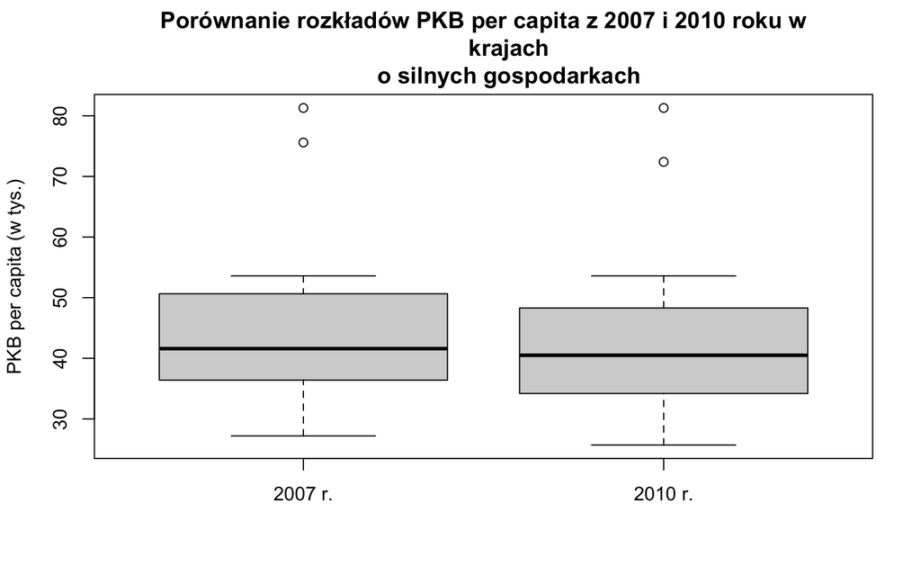

```r
boxplot(silne$gdp2007,
        silne$gdp2010,
        main = "Porównanie rozkładów PKB per capita z 2007 i 2010 roku w
        krajach
        o silnych gospodarkach",
        ylab = "PKB per capita (w tys.)",
        names = c("2007 r.", "2010 r."))
```

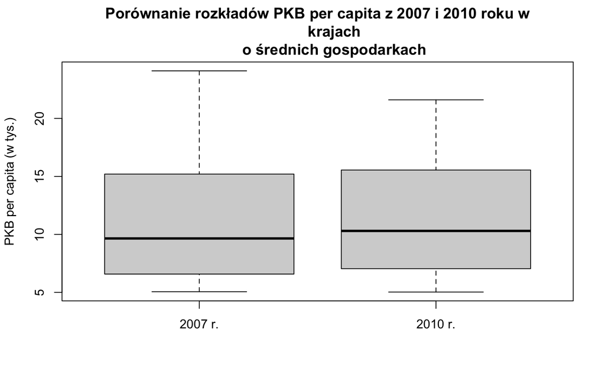

```r
boxplot(srednie$gdp2007,
        srednie$gdp2010,
        main = "Porównanie rozkładów PKB per capita z 2007 i 2010 roku w
        krajach
        o średnich gospodarkach",
        ylab = "PKB per capita (w tys.)",
        names = c("2007 r.", "2010 r."))
```

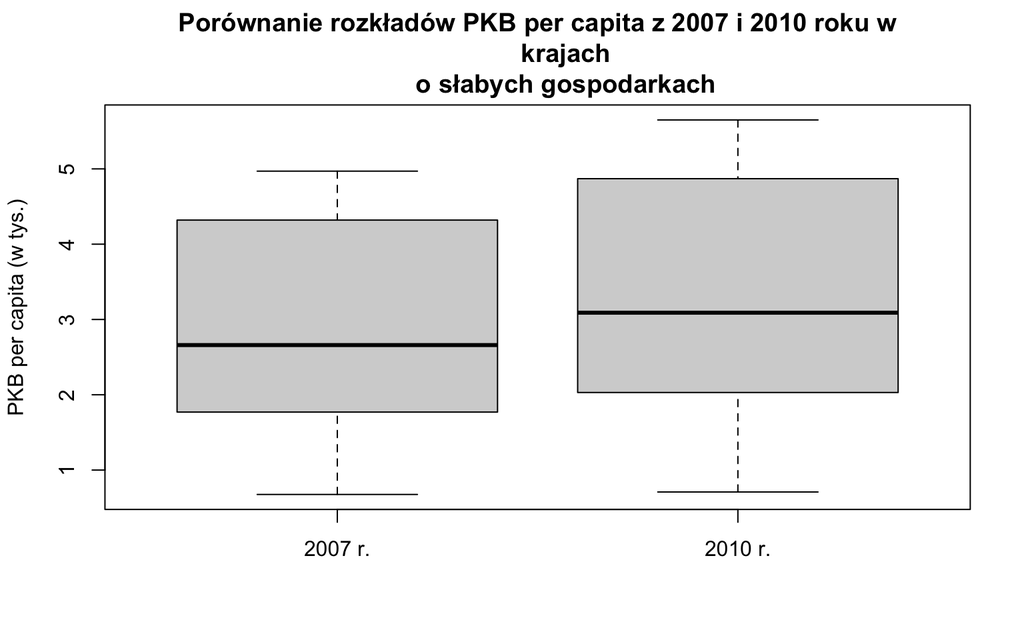

```r
boxplot(slabe$gdp2007,
        slabe$gdp2010,
        main = "Porównanie rozkładów PKB per capita z 2007 i 2010 roku w
        krajach
        o słabych gospodarkach",
        ylab = "PKB per capita (w tys.)",
        names = c("2007 r.", "2010 r."))
```

- Bezrobocie

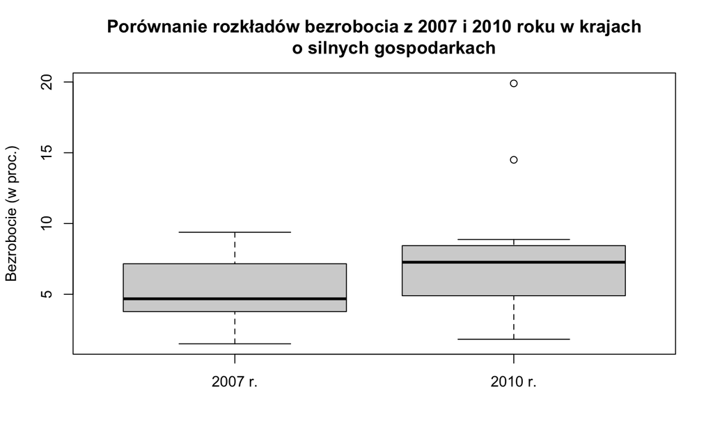

```r
boxplot(silne$unemployment2007,
        silne$unemployment2010,
        main = "Porównanie rozkładów bezrobocia z 2007 i 2010 roku w krajach
        o silnych gospodarkach",
        ylab = "Bezrobocie (w proc.)",
        names = c("2007 r.", "2010 r."))
```

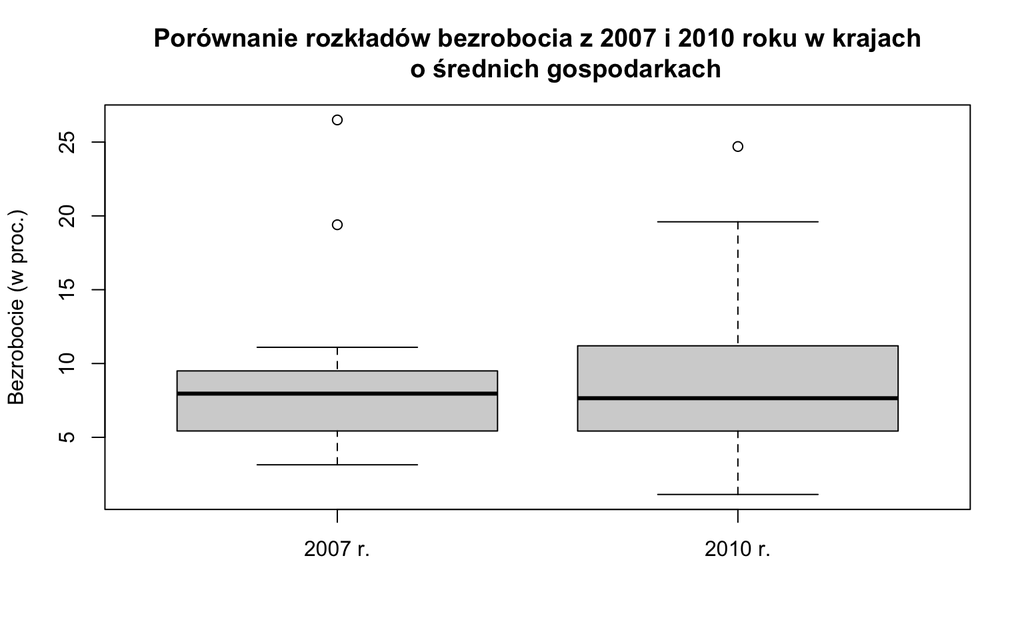

```r
boxplot(srednie$unemployment2007,
        srednie$unemployment2010,
        main = "Porównanie rozkładów bezrobocia z 2007 i 2010 roku w krajach
        o średnich gospodarkach",
        ylab = "Bezrobocie (w proc.)",
        names = c("2007 r.", "2010 r."))
```

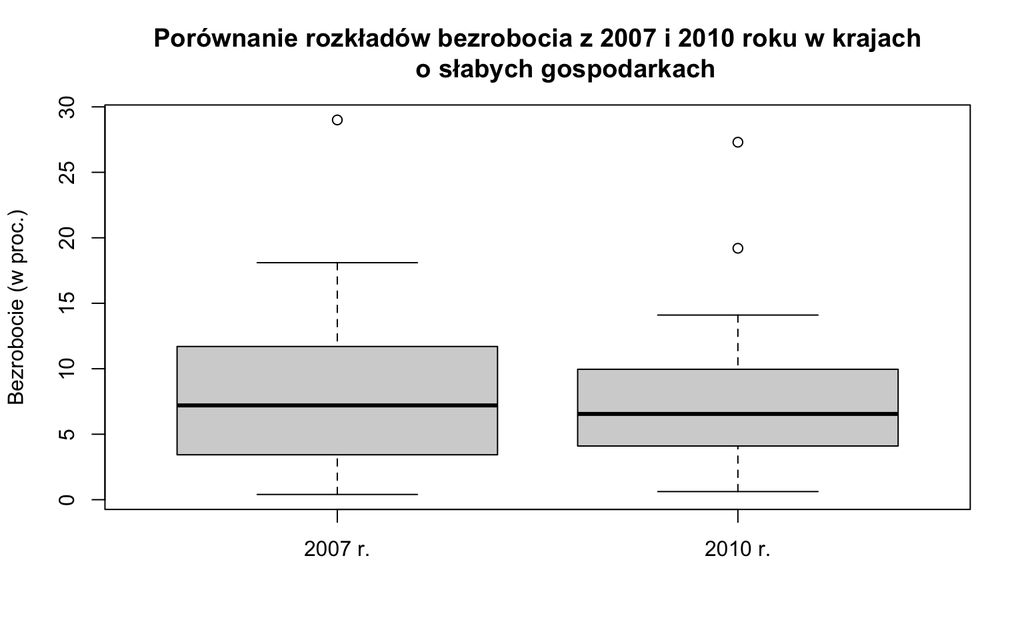

```r
boxplot(slabe$unemployment2007,
        slabe$unemployment2010,
        main = "Porównanie rozkładów bezrobocia z 2007 i 2010 roku w krajach
        o słabych gospodarkach",
        ylab = "Bezrobocie (w proc.)",
        names = c("2007 r.", "2010 r."))
```

- Inwestycje zagraniczne na terenie krajów

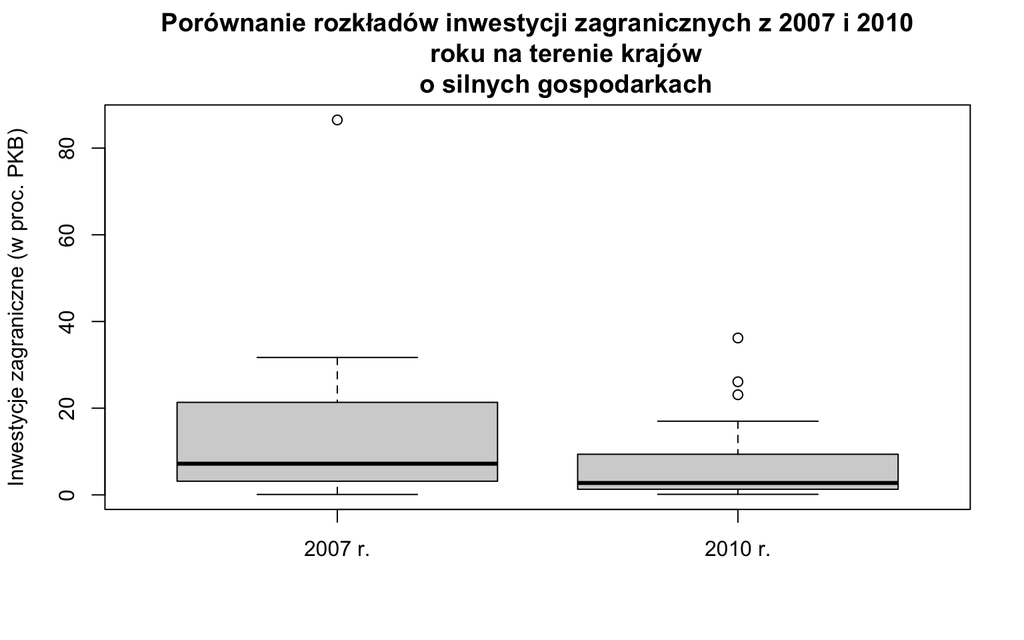

```r
boxplot(silne$foreignInvestments2007,
        silne$foreignInvestments2010,
        main = "Porównanie rozkładów inwestycji zagranicznych z 2007 i 2010
        roku na terenie krajów
        o silnych gospodarkach",
        ylab = "Inwestycje zagraniczne (w proc. PKB)",
        names = c("2007 r.", "2010 r."))
```

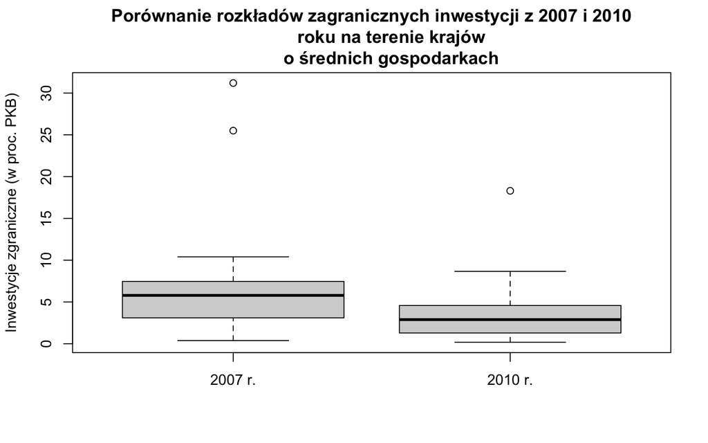

```r
boxplot(srednie$foreignInvestments2007,
        srednie$foreignInvestments2010,
        main = "Porównanie rozkładów zagranicznych inwestycji z 2007 i 2010
        roku na terenie krajów
        o średnich gospodarkach",
        ylab = "Inwestycje zgraniczne (w proc. PKB)",
        names = c("2007 r.", "2010 r."))
```

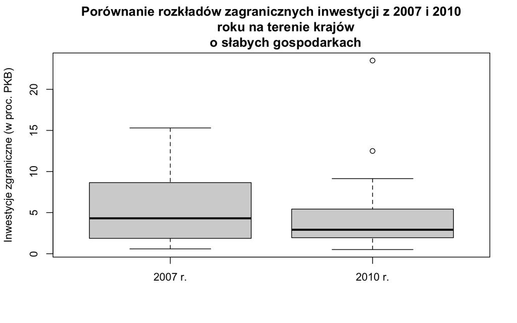

```r
boxplot(slabe$foreignInvestments2007,
        slabe$foreignInvestments2010,
        main = "Porównanie rozkładów zagranicznych inwestycji z 2007 i 2010
        roku na terenie krajów
        o słabych gospodarkach",
        ylab = "Inwestycje zgraniczne (w proc. PKB)",
        names = c("2007 r.", "2010 r."))
```

- Współczynnik Giniego

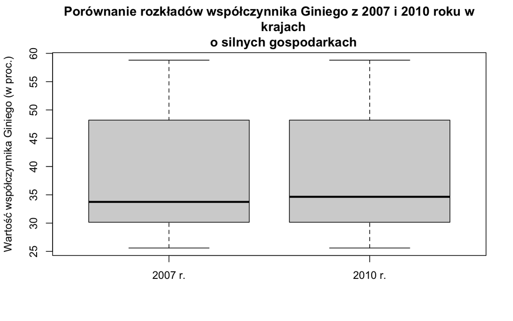

```r
boxplot(silne$gini2007,
        silne$gini2010,
        main = "Porównanie rozkładów współczynnika Giniego z 2007 i 2010 roku w
        krajach
        o silnych gospodarkach",
        ylab = "Wartość współczynnika Giniego (w proc.)",
        names = c("2007 r.", "2010 r."))
```

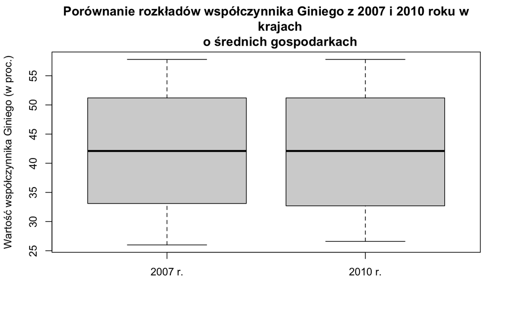

```r
boxplot(srednie$gini2007,
        srednie$gini2010,
        main = "Porównanie rozkładów współczynnika Giniego z 2007 i 2010 roku w
        krajach
        o średnich gospodarkach",
        ylab = "Wartość współczynnika Giniego (w proc.)",
        names = c("2007 r.", "2010 r."))
```

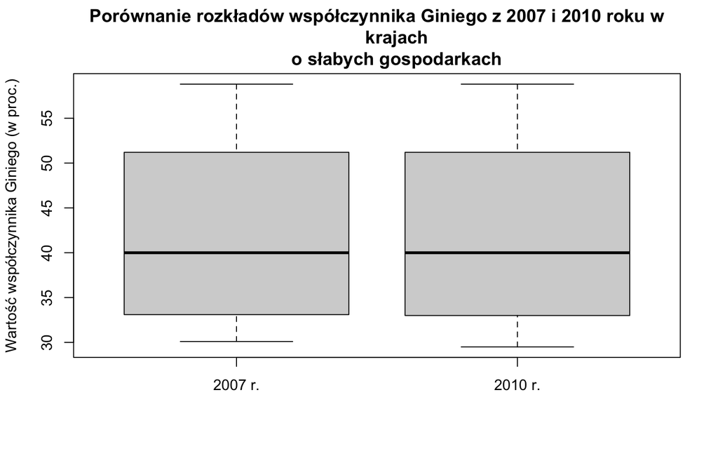

```r
boxplot(slabe$gini2007,
        slabe$gini2010,
        main = "Porównanie rozkładów współczynnika Giniego z 2007 i 2010 roku w
        krajach
        o słabych gospodarkach",
        ylab = "Wartość współczynnika Giniego (w proc.)",
        names = c("2007 r.", "2010 r."))
```

W przypadku miary nierówności społecznej, jaką jest współczynnik Giniego, możemy stwierdzić, że różnice w rozkładzie są minimalne. Wnioskujemy z tego, że kryzys na rynku finansowym nie miał większego wpływu na zróżnicowanie dochodowe w wybranych krajach na świecie.

### 3.4. Korelacje

Ostatnim wstępnym badaniem na naszych danych będzie sprawdzenie ich zmiennych pod kątem korelacji.

Zaczniemy od sprawdzenia zależności pomiędzy zmiennymi ilościowymi. Jak mogliśmy już zauważyć w trakcie wcześniejszych badań, naszym zmiennym daleko jest do rozkładów normalnych. Musimy więc skorzystać z **współczynnika korelacji rangowej Spearmana**:

```r
korelacjaDaneIlosciowe = cor(data[,c("gdp2007", "gdp2010", "unemployment2007",
                  "unemployment2010", "foreignInvestments2010",
                  "foreignInvestments2007", "gini2007", "gini2010")],
          method = "spearman")
korelacjaDaneIlosciowe
```

```
##                             gdp2007     gdp2010 unemployment2007
## gdp2007                 1.000000000  0.99513615     -0.145993617
## gdp2010                 0.995136148  1.00000000     -0.151700297
## unemployment2007       -0.145993617 -0.15170030      1.000000000
## unemployment2010        0.041507887  0.02370023      0.841087235
## foreignInvestments2010 -0.003706205  0.01796008     -0.021288056
## foreignInvestments2007  0.233509394  0.23873302      0.007781851
## gini2007               -0.056248990 -0.03940944     -0.041851206
## gini2010               -0.029864443 -0.01382378     -0.029581610
##                        unemployment2010 foreignInvestments2010
## gdp2007                      0.04150789           -0.003706205
## gdp2010                      0.02370023            0.017960076
## unemployment2007             0.84108723           -0.021288056
## unemployment2010             1.00000000           -0.082203785
## foreignInvestments2010      -0.08220378            1.000000000
## foreignInvestments2007       0.08809461            0.649719831
## gini2007                    -0.10665382            0.033912224
## gini2010                    -0.09157623            0.039561319
##                        foreignInvestments2007    gini2007    gini2010
## gdp2007                           0.233509394 -0.05624899 -0.02986444
## gdp2010                           0.238733017 -0.03940944 -0.01382378
## unemployment2007                  0.007781851 -0.04185121 -0.02958161
## unemployment2010                  0.088094606 -0.10665382 -0.09157623
## foreignInvestments2010            0.649719831  0.03391222  0.03956132
## foreignInvestments2007            1.000000000  0.06514666  0.07043164
## gini2007                          0.065146657  1.00000000  0.99413243
## gini2010                          0.070431636  0.99413243  1.00000000
```

Dla zwiększenia czytelności zaokrąglimy jeszcze wartości współczynników do dwóch miejsc po przecinku.

```r
round(korelacjaDaneIlosciowe, 2)
```

```
##                        gdp2007 gdp2010 unemployment2007 unemployment2010
## gdp2007                   1.00    1.00            -0.15             0.04
## gdp2010                   1.00    1.00            -0.15             0.02
## unemployment2007         -0.15   -0.15             1.00             0.84
## unemployment2010          0.04    0.02             0.84             1.00
## foreignInvestments2010    0.00    0.02            -0.02            -0.08
## foreignInvestments2007    0.23    0.24             0.01             0.09
## gini2007                 -0.06   -0.04            -0.04            -0.11
## gini2010                 -0.03   -0.01            -0.03            -0.09
##                        foreignInvestments2010 foreignInvestments2007 gini2007
## gdp2007                                  0.00                   0.23    -0.06
## gdp2010                                  0.02                   0.24    -0.04
## unemployment2007                        -0.02                   0.01    -0.04
## unemployment2010                        -0.08                   0.09    -0.11
## foreignInvestments2010                   1.00                   0.65     0.03
## foreignInvestments2007                   0.65                   1.00     0.07
## gini2007                                 0.03                   0.07     1.00
## gini2010                                 0.04                   0.07     0.99
##                        gini2010
## gdp2007                   -0.03
## gdp2010                   -0.01
## unemployment2007          -0.03
## unemployment2010          -0.09
## foreignInvestments2010     0.04
## foreignInvestments2007     0.07
## gini2007                   0.99
## gini2010                   1.00
```

Dane te nanosimy na wykres. Potrzebny nam do tego będzie pakiet `corrplot`:

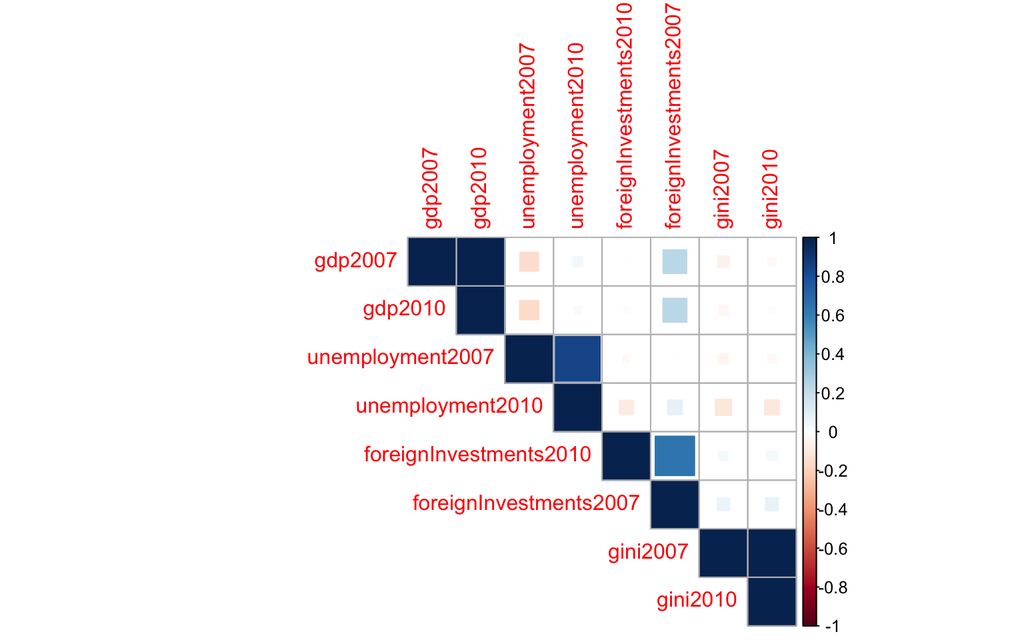

```r
library(corrplot)
corrplot(korelacjaDaneIlosciowe, method = "square", type = "upper")
```

Jak możemy zaobserwować, jedynymi zmiennymi mocno skorelowanymi dodatnio są te same zmienne pochodzące z różnych lat.

Ostatnim już krokiem będzie przeanalizowanie zmiennych jakościowych, czyli w naszym przypadku kontynentu oraz wielkości gospodarki. Stwórzmy najpierw tabele:

```r
table(data[,c("continent", "classification2007")])
```

```
##           classification2007
## continent  gospodarka słabo rozwinięta gospodarka średnio rozwinięta
##   Inny                               6                             2
##   Americas                           5                            10
##   Asia                              11                             4
##   Europe                             3                            11
##           classification2007
## continent  gospodarka wysoko rozwinięta
##   Inny                                2
##   Americas                            1
##   Asia                                5
##   Europe                             12
```

Nie jest ona zbyt czytelna. Do interpretacji posłużymy się więc wykresem (potrzebna nam będzie do tego biblioteka `ggplot2`):

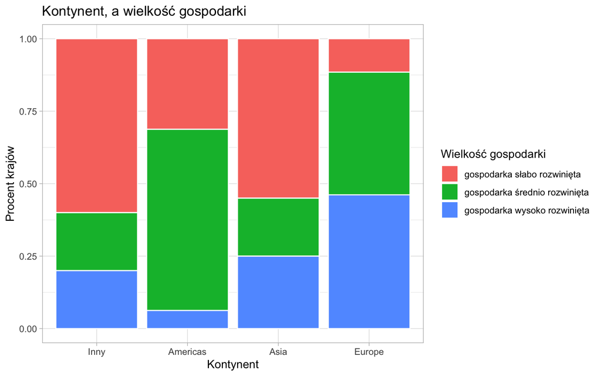

```r
library(ggplot2)

data %>%
  ggplot() +
  geom_bar(aes(x = continent, fill = classification2007),
           color = "white",
           position = "fill") +
  theme_light() +
  labs(title = "Kontynent, a wielkość gospodarki",
       x = "Kontynent",
       y = "Procent krajów",
       fill = "Wielkość gospodarki")
```

Pamiętajmy jednak, że kontynent `Inny` nie powinien być interpretowany. Stwórzmy więc wykres, gdzie nie będzie on zawarty. Zacznijmy od tabeli pomocniczej:

```r
dane_wykres <- data %>%
               filter(data$continent != "Inny")
dane_wykres
```

| country | continent | gdp2007 | gdp2010 | unemployment2007 | unemployment2010 | foreignInvestments2007 | foreignInvestments2010 | gini2007 | gini2010 | classification2007 | classification2010 |
| --- | --- | --- | --- | --- | --- | --- | --- | --- | --- | --- | --- |
| Albania | Europe | 3.040 | 3.580 | 16.00 | 14.10 | 6.11 | 9.14 | 30.2 | 29.5 | gospodarka słabo rozwinięta | gospodarka słabo rozwinięta |
| Argentina | Americas | 12.900 | 13.600 | 8.47 | 7.71 | 2.25 | 2.68 | 46.2 | 43.6 | gospodarka średnio rozwinięta | gospodarka średnio rozwinięta |
| Bahrain | Asia | 22.000 | 21.500 | 5.60 | 1.13 | 8.08 | 0.61 | 48.7 | 48.7 | gospodarka średnio rozwinięta | gospodarka średnio rozwinięta |
| Belgium | Europe | 40.300 | 39.800 | 7.46 | 8.29 | 20.50 | 26.10 | 27.5 | 27.5 | gospodarka wysoko rozwinięta | gospodarka wysoko rozwinięta |
| Bosnia and Herzegovina | Europe | 3.670 | 3.980 | 29.00 | 27.30 | 11.70 | 2.58 | 33.1 | 33.0 | gospodarka słabo rozwinięta | gospodarka słabo rozwinięta |
| Bulgaria | Europe | 6.050 | 6.430 | 6.88 | 10.30 | 31.20 | 3.64 | 27.5 | 27.5 | gospodarka średnio rozwinięta | gospodarka średnio rozwinięta |
| Cambodia | Asia | 0.823 | 0.889 | 1.26 | 0.77 | 10.00 | 12.50 | 41.1 | 41.1 | gospodarka słabo rozwinięta | gospodarka słabo rozwinięta |
| Canada | Americas | 42.100 | 41.200 | 6.04 | 8.06 | 8.20 | 1.84 | 40.1 | 40.1 | gospodarka wysoko rozwinięta | gospodarka wysoko rozwinięta |
| Chile | Americas | 11.200 | 11.800 | 8.43 | 8.42 | 7.81 | 7.38 | 57.8 | 57.8 | gospodarka średnio rozwinięta | gospodarka średnio rozwinięta |
| China | Asia | 4.320 | 5.650 | 4.00 | 4.10 | 4.40 | 4.00 | 57.8 | 57.8 | gospodarka słabo rozwinięta | gospodarka średnio rozwinięta |

[output cut: 52 more lines]

I przejdźmy do narysowania wykresu:

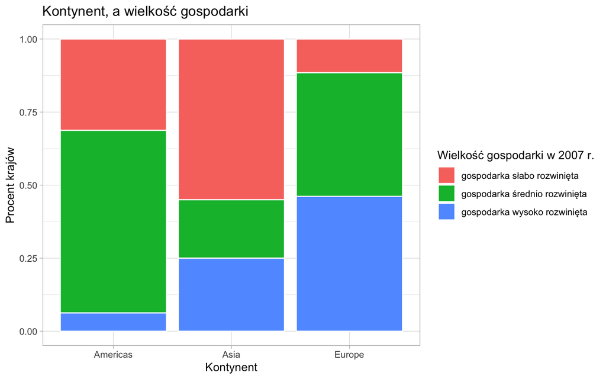

```r
dane_wykres %>%
  ggplot() +
  geom_bar(aes(x = continent, fill = classification2007),
           color = "white",
           position = "fill") +
  theme_light() +
  labs(title = "Kontynent, a wielkość gospodarki",
       x = "Kontynent",
       y = "Procent krajów",
       fill = "Wielkość gospodarki w 2007 r.")
```

Jak możemy zauważyć, największy udział krajów wysoko i średnio rozwiniętych jest w Europie. W Amerykach natomiast przeważają kraje o średniej wielkości gospodarek. Co ciekawe, w Azji znajduje się więcej krajów wysoko rozwiniętych niż w Amerykach, ale za to charakteryzuje się ona również największym udziałem krajów o słabych gospodarkach (oczywiście spośród naszych danych).

Z ciekawości sprawdźmy jeszcze, czy rozkład ten znacząco zmienił się w 2010 roku:

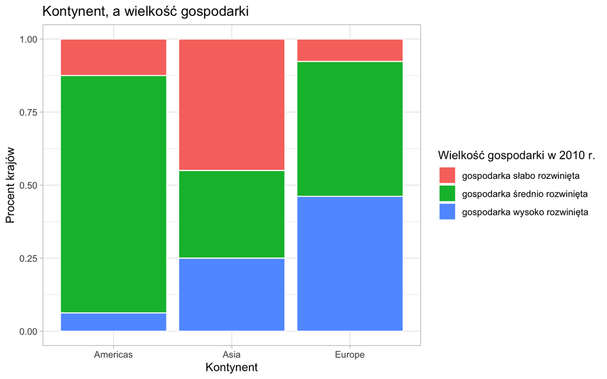

```r
dane_wykres %>%
  ggplot() +
  geom_bar(aes(x = continent, fill = classification2010),
           color = "white",
           position = "fill") +
  theme_light() +
  labs(title = "Kontynent, a wielkość gospodarki",
       x = "Kontynent",
       y = "Procent krajów",
       fill = "Wielkość gospodarki w 2010 r.")
```

Jedyną znaczącą zmianą jest powiększenie się dominacji gospodarek średniej wielkości w Amerykach.